# Stranded Series Bible

The world building guild for the Stranded Series!!

Ben Wilson

# Overview

**Stranded** is a steampunk novella series by Ben Wilson. Eighteenth-Century British-Americans discovered advanced technology in the Ohio Territory at the end of the Seven Year’s War.

The saga launches with season one: a web series exploring the struggle between the English, Rebels and Iroquois over who would control the newly-discovered ancient technology.

## Format

A reader should complete a novella in roughly two hours of reading, or under four hours listening via Audible. This size was chosen to favor air travel (TODO: [#31](https://github.com/Merovex/stranded-series/issues/31), audience psychographics). Each season will be self-contained, though with storylines that may delay resolution until a subsequent series. A season climax will close out the season, but leave the reader wanting the next one.

This is an alt-history Science Fiction series. Need to explain the genre (horror, comedy, etc.) Loop in the major tropes.

Each season comprises eight novella episodes (26,500±2,500 words or 80±8 pages). Therefore, each season is 212,000 words (191 to 233 @ ± 10%), or about three 70,000 novels. Each novella comprises 8 three-scene segments or 24 scenes (~1100 words per scene).

- Reading pace: Average adult reading time is 220wpm. Therefore, each novella should take about two hours to read ± 10%
- Listening pace: Audible standard voice pace is 125wpm. A novella should complete in about 3.5 hours.

### Episode Pattern

- **Pattern.**
  - Albert has a problem.
  - His solution works but, but puts him at odds with the aliens. -
  - He solves that problem, but it requires him to become more like the aliens.
- **Stories.**
  - A — Episode problem.
  - B — (bonum) Rescue efforts -
  - C — (malum) Alien plot against Albert;- -
  - D — Alien rebellion

## Audience

In AUDIENCE you should clearly define your target audience; not just by age or gender but also by demographic, interests, habits, other media they consume, other activities they engage, what professions they occupy, what beliefs or values they may hold. Audiences are not so simplistic as to be defined simply by how old they are and what sex they are…!

Also take into consideration the audiences of other shows and aim your project to appeal to the same audience as a similar series, or one in the same style or genre.

If possible specify the network, broadcaster or channels most appropriate.

TODO: [#31](https://github.com/Merovex/stranded-series/issues/31)

*Who is the target audience? a narrative description of your target audience. This would be the anonymous “someone” you write to in your novels.*

- **Show Cross.**
  - [Grizzly Adams](https://en.wikipedia.org/wiki/The_Life_and_Times_of_Grizzly_Adams) - a man who is forced out on his own and wants to return home.
  - [Macgyver](https://en.wikipedia.org/wiki/MacGyver) - a man who is able to solve problems with ingenuity
  - [Breaking Bad](https://en.wikipedia.org/wiki/Breaking_Bad) - a man who makes things worse in an effort to make things better.

## Themes & Concepts

- **Theme.** Stranded asks whether one can glorify God while focusing on self-aggrandizement.

### Themes

THEMES are Unifying Subjects

Themes provide the idea-space the production and story will play out in and which will unify otherwise disparate storylines and characters.

Themes shouldn’t present arguments or perspectives but rather be the macro-level topic to be explored. It provides a touchstone of reference for any given episode. “How does each episode, each character explore the themes?”

Love, Justice, Revenge, Redemption, Betrayal, Hope, Progress, Power, Corruption… Big dynamic emotive words make great themes for unifying a series.

### Concepts

CONCEPTS represent the “what if” questions of your series. Strong concepts are often the result of bringing together things that otherwise don’t belong, or scenarios that are extraordinary in some way as to prompt questions on the mind of an audience.

Concept overview should be like:

> Person of Interest is an American science fiction crime drama television series. John Reese, a former CIA agent who is presumed dead. He is approached by a mysterious billionaire named Harold Finch who is trying to prevent violent crimes before they happen by using an advanced surveillance system dubbed “The Machine” that provides the SSN of a POI (person of interest) who will be involved in an imminent lethal crime as either a perpetrator or a victim. (The episode driver) Their unique brand of vigilante justice attracts the attention of two NYPD officers, Joss Carter and Lionel Fusco, whom Reese uses to his advantage as he investigates the POI. Reese and Finch are later aided by Samantha “Root” Groves, a highly intelligent computer hacker and contract killer whom the Machine later identifies as its “analog interface”, and Sameen Shaw, a former ISA assassin who unknowingly dealt with the “relevant” numbers found by the Machine. During the course of the series, 103 episodes of Person of Interest aired over five seasons.

**Logline.** Wrongfully accused of murder, anthropologist Albert Strand flees the orbital to the alien world below. Albert must adapt to the alien society and its intrigues, and decides to use his superior understanding of technology to his advantage.

## Series Plot / Outline

**a one-page (4-5 paragraph) summary of the world, major characters and central tension.**

In the 18th century, humanity discovered advanced alien technology in the Toltec Indian mounds. Over the next 150 years, society embraces the technology and develops interstellar travel via the slipstream, all while retaining paranoid nationalism. When they encounter other human settlements on alien worlds, they chose to study them out of concern that “alien” use of slipstream technology puts them at risk.

Albert Strand is a descendent of the original discoverer of the Indian mounds and lives under that shadow. Putting career before family, he lobbied hard to be assigned to the Orbital.

a 1-2 page that gives an overview of the characters, major series arcs.

1. Paragraph introduces the main character and the central series plot.
2. Paragraph explains the major characters & relationships to main character and one-another.
3. Paragraph summarizes major series sub-plots, one sentence per subplot. Highlight on the first major subplot to address.
4. Paragraph of season two summary in four sentences: the core season conflict, new characters/conflicts. Service the subplots.
5. Ditto each new season. Close each subplot introduced in the sub-plot paragraph. Introduce a new one as necessary.

# Setting (Where & When)

*Setting details (where & when) that backdrop the series. This is lengthy for Science Fiction, but shorter for a suburban housewife drama setting.*

**Stranded** is an alternate history setting diverging in the 18th Century after [technologic acceleration](https://github.com/Merovex/stranded-series/blob/master/series-bible/AA-Appendix/Tropes/GivingRadioToTheRomans.md) in British North America. The British believe the technology to come from ancient aliens they named the “Toltec” after the native mounds where the technology was discovered; there are no aliens in the series. Access to advanced technology early set the British on a path to global dominance unabated in the 20th Century.

In the 18th Century, Toltec discoveries led to advanced weapons (automatic rifles). In the 19th Century, Toltec Neutrinovoltaic technology accelerated the industrial era. By the early 20th Century, Brits were in space and leveraging Toltec technology for [Slipstream](https://github.com/Merovex/stranded-series/blob/master/series-bible/08-Science-Cosmology/slipstream.md) (faster-than-light) travel. Traveling the Slipsteam reveals “[Elysion](https://github.com/Merovex/stranded-series/blob/master/series-bible/04-Locations/Elysion/00-elysion.md),” an inhabited earth-like planet two knots from Earth. Afraid this was the alien homeworld, the British set up on an abandoned Toltec orbital to observe Elysion, which led to Elysian anthropology.

Elysion inhabitants are humans genetically identical to Earth. Albert encounters the Hela, a dark-skinned, Indo-European-appearing ethnicity speaking what Albert determines is an older Germanic (Icelandic) language. The Hela, technologically in the Renaissance, are in the early stages of a civil war, with a rival branch of the ruling family seeking to gain power.

## Timeline

### 1763-1783: Point of Divergence

The Seven Year’s War occurs as the fourth intercolonial war between England and France (1756-63). The war progressed as depicted in history. The relationship strain between England and its 13 American continental colonies (The Thirteen or British American) built up with increased taxation. After the Stamp Act was passed and repealed (1765-66), **calmer heads prevail. The [Declaratory Act of 1766](https://en.wikipedia.org/wiki/Declaratory_Act) never occurs and we diverge from our timeline.**[^1]

In 1766, Parliament invited a delegation from each of The Thirteen to work out differences that included Benjamin Franklin. This extended negotiation (1766-69) blunted Radical demands for independence. However, a splinter from the Sons of Liberty continued the (now unpopular) fight for American Independence. This splinter movement is a key area of conflict in Discovery Season.

These negotiations led to legislation that addressed British North America grievances and allowed both sides of the Atlantic to move forward in a tense harmony.

#### Rights of Englishmen Act of 1769

The Rights of Englishmen Act of 1769 extended all customary rights & privileges to native-English speaking white settlers in British North America. This created some frustration with Caribbean Colonials. Many Caribbean colonists remedied this by establishing residence in Charles Town, Carolina.

This disenfranchised French-Canadian residents. Many raised their children speaking English to extend these rights to them.

#### British North America Act of 1771

British North America sought representation in Parliament. The government agreed, providing the colonies restructured. This act transformed the continental colonies to six self-regulated provinces: Canada, New England, Pennsylvania (includes IRL New York), Virginia, Carolina, & Georgia. This act further gave those provincial governments representation in the Parliament of the United Kingdom. Ohio province is added in 1803, encompassing IRL Northwest Territory United States.

#### Rights of Religious Liberty Act of 1772

British North America sought religious liberty. Parliament sought its debts to be paid and taxation for its recurring budget. Some of this budget paid Church of England (CofE) ministerial salaries. This act permitted provinces to manage their own religious affairs. This effectively abolishes CofE in British North America except for Virginia and Carolina. The lack of CofE minsters removes British North America’s obligation to pay that portion of the budget.

#### War Debt Equity Act of 1772

In the *quid pro quo* for the Rights of Religious Liberty Act, British North America provinces agreed to take on half of the Government’s debt incurred by the end of the French & Indian War. Whether this meant war debt or total debt was a matter of disagreement that was settled during the Napoleonic Era. The Seven Years’ War nearly doubled Great Britain’s national debt, so the question of whether British North America provinces accepted a quarter or half of the debt was no small issue.

### 1766-1840 The Indian Problem.

At the end of the French & Indian War, there were estimated to be as many Indians as white settlers in North America (~4.5 million).[^2]

- Battle of Fallen Timbers in 1794. The subsequent Treaty of Greenville 1795 opened the way for settlement of southern and western Ohio.
- TODO: [#35](https://github.com/Merovex/stranded-series/issues/35) Account for Indian relations to start of series

### 30 November 1782: Discovery of Toltec Technology

Ephraim George Biggs discovered what became known as the **Toltec Mound**.

### 1783-1848: Eradication of African Slavery

- 1772 - Somerset’s Case holds there is no basis for slavery in English law, and held that laws supporting slavery were against Natural Law. This extends to BNA.
- 1787 - Wilberforce’s Anti-Slavery Society struggled against London Society of West India Planters and Merchants who fought against abolition of slavery.
- 1807 - During a break in the **French Troubles**, England de-legalizes trans-shipment of slaves on the Oceans and between non-connected provinces.
- 1833 - “Apprenticeship Act of 1833” ends slavery in all British holdings by stages & “apprenticeships.” Chattel is immediately repudiated by Parliament, meaning that African children were born free. Slave owners were mollified by a tax break for each freeborn child. Slave owners were compensated by tax. American high-society slave owners were well-compensated, lower-class owners were not, leading to some animosity.
- 1846-48 - Apprenticeships ended in American provinces (Virginia, Carolina, Georgia) to increase representation in Parliament, leading to local civil conflicts in each province by the lower class “masters,” which was put down by General Scott.
- Need to research Parliament in the 19th Century.

### 1783-1815: French Troubles

The French economy struggles under reparations required in the Treaty of Paris. The government gets caught up in various schemes to pay the debt that results in a popular uprising in 1783.

Napoleon is involved as a republican during the early stages of the struggle, and gains power as expected. England takes control of New Orleans when Napoleon moves on Spain, and keeps it. Napoleon sends troops in 1801, triggering the war between England and France & Spain (the latter as a vassal to France).

This “Napoleonic War” is ended by British & American deployment of Toltec weaponry in 1815. Napoleon is executed and a new French king is placed on the throne. This ends the French Troubles.

The Louisiana Territory is kept by England as compensation for the war, and to further safeguard English interest and control over Toltec artifacts.

### 1815-1911: Post-Toltec Europe

Once the English defeat the French in 1815 with advanced Toltec weapons, the Congress of Vienna is established. This redrew borders as per the standard timeline. Other great powers were concerned over England’s technology. Technology espionage starts on the battlefield with some weapons stolen.

## Geography

### Charlotina (Ohio)

Following the 1763 Treaty of Paris, Charlotina was established as a Crown colony encompassing the IRL US Northwest Territory boundaries. The argument and name emerged in a 1764 Scottish pamphlet entitled *The Expediency of Securing our American Colonies by Settling the Country Adjoining the River Mississippi, and the Country upon the Ohio, Considered*.

Charlotina included the region lying west of the Maumee and Wabash rivers; north of the Ohio River; east of the upper Mississippi River; and south of the Great Lakes. These boundaries would include portions of modern-day Minnesota, Ohio, Indiana, and the entirety of Michigan, Illinois, and Wisconsin. Charlotina will later include the modern-day cities of Chicago, Milwaukee, Toledo, Detroit, Fort Wayne, and parts of Minneapolis and St. Paul.

### Mississippi

Following the 1763 Treaty of Paris, Mississippi was established as a Crown colony encompassing the IRL US Southwest Territory boundaries. The Eastern boundary is established by the continental divide, with all Mississippi-basin areas South of the Ohio belonging to Mississippi. The boundary with Georgia & Carolina is separated by the Chattahoochee River with Mississippi encompassing all land West until the Chattahoochee head water, then the shortest-route to Carolina. The North boundary is the Ohio River. The West boundary is the Mississippi River. The South boundary is Spanish Florida, until Britain gains control, then it is the Gulf of Mexico. These boundaries would include portions of IRL modern-day Mississippi, Alabama, Tennessee, Kentucky, Georgia and West Virginia. Mississippi will later include the modern-day cities of (TN) Memphis, Nashville, Knoxville, Chattanooga, Clarksville, Murfreesboro, (MS) Jackson, (AL) Huntsville, (KY) Louisville, and Lexington. Atlanta & Tallahassee are on the Georgia side of the Mississippi-Georgia border.

### Original Thirteen colonies & Canada

Prior to about 1760, north of Spanish Florida, the Appalachian Divide represented the boundary between British and French colonial possessions in North America. After the French & Indian War, England sought to clarify the boundaries. Under the *British North America Act of 1771*, the Original Thirteen colonies were re-organized into six provinces. Each of the sections below discusses each province in a bit more detail.

#### Canada

Canada encompasses all land North of the St. Lawrence, which includes the Hudson Bay area and Quebec (both separated by the Laurentian Divide). Also added is Prince Edward Island. Areas South of the St. Lawrence were ceded to New England. The Quebecois were disenfranchised by the *Rights of Englishmen Act of 1769* for nearly two generations.

#### New England

The colonies of Massachusetts, Connecticut, Rhode Island and New Hampshire were consolidated into the Province of New England. This included all land South of the St. Lawrence, which extends to New Brunswick, Nova Scotia and parts of Quebec. All land east of the Hudson becomes New England as well, except for Manhattan and Long Island. This led to considerable resistance by the Sons of Liberty, and led a small rebellion put down by Virginia and Pennsylvania.

#### Pennsylvania

The colonies of New York (West of the Hudson, Manhattan, & Long Island), New Jersey, and Pennsylvania are consolidated into the Province of Pennsylvania. The Western border was fixed with Charlotina as a true North-South line from Pittsburgh North to Lake Erie and South to the Mason Dixon boundary with Virginia. Pennsylvania divided their Provincial Assembly seats equally among the former colonies.

#### Virginia

The colonies of Delaware, Maryland and Virginia were consolidated into the Province of Virginia. The boundary with Pennsylvania was finalized by the Mason Dixon line; consistent with the Original Timeline. The boundary with Carolina was likewise finalized along the 36°30’ parallel; consistent with the Original Timeline. The Western border with Mississippi and Charlotina by the Atlantic & Mississippi Watersheds described by the Appalachian Divide. Virginia encompasses all parts of West Virginia and Virginia that flow into the Atlantic. Mississippi and Charlotina encompass those parts of West Virginia and Virginia that flow into the Mississippi.

#### Carolina

The colonies of North and South Carolina were consolidated into the Province of Carolina. The boundary with George is the Savannah River with the two tributaries of the Savannah, the Tugaloo River and the Chattooga River, form the northernmost part of the border; consistent with the Original Timeline. The Northern border is along the 36°30’ as identified by King Charles II, and runs to the Appalachian Divide; consistent with the Original Timeline.[^3]

#### Georgia

The colony of Georgia became the Province of Georgia. When Florida is later incorporated, Georgia extends South to capture the entire peninsula. The boundary with Mississippi is separated by the Chattahoochee River with Mississippi encompassing all land West until the Chattahoochee head water, then the shortest-route to Carolina. Its border with Carolina is consistent with its Original Timeline border with South Carolina.

## Science & Technology

This section discusses the Science and Technology of Stranded. This includes anything related to Cosmology (the science of the origin and development of the universe).

### Power (Engines, Electricity & Locomotion)

Engine development was slower as it derived from patent research. Dates below indicate when they were commercially available.

- 1820 - Electricity using hydropower. Biomass generators commercially available by 1839
- 1826 - Oil discovered, knock 20 years off of evolution of oil
- 1828 - Diesel engine (called the biomass engine)
- **1836 - JL Chandler reverse engineered neutrino power, receiving a patent on the Chandler Power Cubes. (15 June)**
- 1836 - Gasoline engine - limited use to highly urban environments due to poor infrastructure and lack of access to gas.
- 1839 - Diesel locomotive - Slow and mechanically inefficient
- **1842 - First Neutrinovoltaic powered (NVP) locomotive using the MicroChandler Power Cube.**
- 1845 - Gasoline automobile limited utility in favor of biomass trucks.
- **1845 - Chandler died (29 December), Chandler’s patent on the CPCs lapses in 1846.**
- **1859 - First Neutrinovoltaic powered (NVP) automobile by Tucker. [See real timeline](https://en.wikipedia.org/wiki/History_of_the_electric_vehicle#Electric_model_cars)**
- 1861 - Latimer Clark and Sir Charles Bright coined the name “volt” for the unit of resistance. **This countered the growing interest in naming it the “Chand” or “Chandle” as part of the resistance to Toltec influences. The term was in widespread use by 1869.**
- **1869 - NVP “Victoria” Taxies introduced by Walter C. Bersey** (10y early, see Images)
- **1888 - NVP oceangoing ships** (Oil-burning naval ships)

#### Chandler Neutrino Power Cube

**Johnathan Link Chandler** was the first to reverse engineer the Toltec Neutrino Engine (called Annichites by the Toltec), creating the Chandler Neutrino Power Cell, and Power Cubes. The NVPC (Neutrino-voltaic Power Cube) is a 2.25" cube. Chandler encased them in a thin layer of white porcelain with four brass electrodes flush with the body. This allows the cubes to be tethered to create the larger power cubes.

- Chandler Power Cube (CPC)
- Neutrino Power Cell (NPC)
- Stone (st.)

| Name | Watts | HP | Size | Units | Side | Weight |
| --- | --- | --- | --- | --- | --- | --- |
| Neutrino CPC | 25 |  | 1 | 1 | 3" | 0.5# |
| 8-by CPC | 200 |  | 2 | 8 | 5" | 4.0# |
| 1-st | 675 | 1 | 3 | 27 | 7" | 1 st |
| 5-st Domestic | 4 kW | 4 | 5 | 125 | 1’ | 5 st |
| 20-st | 13 kW | 17 | 8 | 512 | 2’ | 20 st |
| 80-st | 55 kW | 74 | 13 | 2197 | 3’ | 80 st |
| 330-st | 232 kW | 310 | 21 | 9261 | 4’ | 3 t |
| 10-t | 1 MW | 1.3k | 34 | 39.3K | 7’ | 10 t |
| 40-t | 5 MW | 5.6k | 55 | 166K | 11’ | 42 t |
| 180-t | 18 MW | 23.6k | 89 | 705K | 17’ | 177 t |
| 750-t | 75 MW | 100k | 144 | 3M | 27’ | 747 t |
| 3100-t | 317 MW | 424k | 233 | 12M | 44’ | 3 kt |
| 14000-t | 1340 MW | 1.8M | 377 | 54M | 71’ | 13.4 kt |

When humanity found the Toltec orbitals, they saw just how closely Chandler’s design worked, with a single 225-ton CPC.

#### Neutrino Energy

- The neutrino is the source of abundant, clean, renewable energy.
- Neutrinovoltaic - a low voltage system of 12/24/48V DC
- **Neutrino Film** is “a film made of metal or a metal alloy, in particular a film made of aluminum or an aluminum alloy, a so-called neutrino or ntrino film (registered trademarks), to a method of production and to a use of a film made of metal or a metal alloy.” [WO2016142056A1](https://patents.google.com/patent/WO2016142056A1/en)
- **Neutrino Power Cubes** are highly sophisticated power cells that have the advantage of being able to supply energy in complete darkness. They do this by harnessing the kinetic energy created by invisible waves of cosmic radiation, transforming it into micro-vibrations in a complex resonation process facilitated by super-symmetrical coatings on a stable substrate. And because these power cells can be stacked on top of one another, they are more compact and efficient than today’s solar cells and far less easily damaged.
- **Neutrino Energy Harvesting** is when energy can be derived from many different sources such as radio waves, vibrations, heat, or light, and these sources can be either natural or artificial. Solar cells convert light; thermoelectric generators convert heat flux (temperature differences); and Neutrino Power Cubes convert vibrations caused by neutrinos and anti-neutrinos into electricity.
- Today is the era of “**homo electricus**,” and electricity will continue to play an important role in mankind’s never-ending strides towards further development.

##### References

- [Neutrino energy: harnessing the power of cosmic radiation](https://www.power-technology.com/features/neutrino-energy-harnessing-the-power-of-cosmic-radiation/)
- [Neutrino energy](https://neutrino-energy.com/)
- [Neutrino Wiki](https://neutrino-wiki.com/)

### Slipstream Travel

This section discusses faster-than-light (FTL) space travel.

Slipstream technology describes the ability to get from Earth to Slipstream and through Slipstream. Odyssey Limited is the Crown chartered company responsible for exploitation of Slipsteam tech and non-solar system exploration.

#### Timeline

- 1828 - Slipstream travel discovered in computer
- 1831 - Society for Slipsteam Research (SSR) established
- 1854-1895 - Building out the infrastructure
- 1882 - Toltec Centennial
- 1895 - Earth to Orbit - Reusable spacecraft based on Toltec designs
- 1898 - First Man on the Moon
- 1901 - Orbit to Slipstream
- 1905 - First successful jump between Earth and another system
- 1905 - SSR Renamed Odyssey, Ltd.
- 1914 - Slipstreams all mapped out
- 1923 - Orbital in Elysion system started
- 1929 - Elysion Orbital operational
- 1936 - Elysion Orbital attacked

### Space Travel

This section discusses slower-than-light (STL) space travel.

#### Spacecraft

**Design.** Spacecraft are symmetrically built around a frame. Propulsion is reaction-based, so a considerable amount of the ship’s total mass is its consumable reaction material. Ships cannot travel in atmosphere as gravity will crush the frame. Travel between planet and orbitals is done through interface vehicles. **Ships are built like office towers** (Pringles cans), with small decks stacked on top of each other, which experience gravity only when the ship is under thrust.

**Travel.** When traveling, ships accelerate to the midpoint of their journey, turn around, and decelerate. No dogfights, no Immelmann or Crazy Ivan maneuvers. Safe travel means accelerating to a midpoint at 1.0-1.5 G, turn around, decelerate at 1.0-1.5 G, over a period of several dys.

**Heat.** Heat is always a problem. An inability to dissipate heat can get one into trouble. Burn your engines too much, or fire too many lasers, and you start to have problems in combat yourself, because of an inability to radiate heat into the darkness of space.

**Payload.** These concerns combine to suggest that a ships payload section is relatively small (10-30% of the ship’s mass), Given the limits on payload, space for crew, weapons, cargo, and extras is limited. Slipdrives are small to allow FTL travel within the design constraints (i.e. we wanted ships both with slipdrives and with guns), and so the limit on FTL travel comes from the point of departure, well above the ecliptic of the system.

#### Slipstream

Knot

#### Inner System

The table below describes the constraints of space travel. Most space ships are fuel constrained based on their acceleration ability, shown by the Duration. Travel between Earth and the Slipsteam is within the limits of those ships. Those with extended durations can travel four times further than regular ships, at the expense of crew comfort. Those ships could safely make it to Uranus and back, but not to the Oort cloud.

- Civilian ships never accelerate at 1G (V-shift 3) beyond a full day.
- Military ships never accelerate at 2G (V-shift 5) beyond a full day.
- Slipknot (5AU) Moon, Mars (1.5AU), Uranus (19AU), Oort (1ly) columns all refer to travel time from Earth to those (average distance) locations.
- To get 1AU, multiply Mars by 0.67 (1G = 3.7dys)

TODO: Confirm whether the numbers are based on full-time or limited acceleration.

| V | Acc.(g) | Duration | Slipknot | Moon | Mars | Uranus | Oort |
| --- | --- | --- | --- | --- | --- | --- | --- |
| 0 | 0.01 | 130 dys | 65 dys | 34 hrs | 17 dys | 116 dys | 40.0 yrs |
| 1 | 0.1 | 40 dys | 20 dys | 11 hrs | 5.5 dys | 35.6 dys | 12.5 yrs |
| 2 | 0.5 | 18 dys | 9 dys | 5 hrs | 2.5 dys | 16.0 dys | 5.5 yrs |
| 3 | 1.0 | 13 dys | 6.5 dys | 3.5 hrs | 2.0 dys | 11.5 dys | 4.0 yrs |
| 4 | 1.5 | 10 dys | 5 dys | 3 hrs | 34 hrs | 8.9 dys | 3.0 yrs |
| 5 | 2.0 | 9 dys | 4.5 dys | 2.5 hrs | 29 hrs | 7.6 dys | 2.8 yrs |
| 6 | 3.0 | 8 dys | 4 dys | 2 hrs | 24 hrs | 6.3 dys | 2.3 yrs |

### Weapons Development

Weapons development in the 19th Century accelerated based on access to working Toltec weapons. Toltecs continued to use slug-throwing weapons, so this accelerates the introduction of semi- and full-automatic weaponry. Based on the Neutrino discoveries, scientists speculate the Toltec withheld their more advanced weaponry from Earth.

#### Personal Weapons

Several weapons were found in the Toltec Indian Mound Temple. Anglo-American first reverse-engineered the actual weapon as the first generation. A second iteration led to improvements.

- 1803 - Pennsylvania Toltec Arms, Ltd. (PTA Ltd.) chartered by Jacob Dickert and Martin Meylin Jr. to reverse-engineer & produce Toltec weapons, moved by royal request to Harper’s Ferry.
- 1807 first successful reverse-engineered prototype built
- 1814 - PTA Ltd. completed 4,000 rifles Harper’s Ferry Model 1803, also known as the Toltec Battle Rifle Model ’03 (HFM-03, TBRM-03 or BRM-03) essentially the StG-44. This is a straight reverse-engineer
- 1815 - Battle of Waterloo turned by use of the BRM-03
- 1815 - PTA Ltd. charter revoked. Crown forms “Harpers Ferry Arsenal” with the same leadership
- 1819 - The Model 1819 (M1819, AK-47) “Hall Rifle” replaces the BRM-03
- 1808-17 - Semi-automatic pistols reverse engineered and improved, essentially the boxy Glock is the improved result.

#### Field Artillery

The cannon was quickly replaced by what we would consider modern field artillery.

- 1813 - Reverse engineer of Toltec field gun complete. Never entered mass production.
- 1818 - the Harper’s Arsenal Ordinance (HAO) 5-inch howitzer fielded. Deemed to bulky to deploy in service
- 1829 - the [HAO Improved (HAOi) 4.5-inch](https://en.wikipedia.org/wiki/QF_4.5-inch_howitzer) accepted by British military
- 1830 - HAOi 4.5-inch placed in service.

## Discovery Season

### Mississippi Land Company

The Mississippi Land Company was a land company formed in 1763 following the British victory in the French and Indian War (1754–1763) in North America. The company was formed to acquire land grants in the vast former New France region between the Appalachian Mountains and the Mississippi River ceded by France to Britain after the war.

The Mississippi Land Company was formed by colonial Virginians including George Washington, John Augustine Washington, Richard Henry Lee, Arthur Lee, and William Fitzhugh. The company hoped to establish a new colony in the Mississippi Valley by petitioning the Crown for 2.5 million acres (10,000 km²) in what became Charlotina and parts of northern Mississippi.[^4]

### Parliament of British North America

The British America Act of 1771 restructured British America (the continent) into six provinces: Canada, New England, Pennsylvania (includes IRL New York), Virginia, Carolina, and Georgia. This led to six Provincial Assemblies.

Each Assembly was bicameral, with the House of Lords appointing the Council of State and province landowners electing members of the Council of Commons. The Crown appoints a Lieutenant Governor as executive to each Province, as well as the Governor of British America. Each provincial government appoints 9 seats to the British Parliament, for a total of 54 seats in the Commons. Compare this with the 45 seats given to Scotland in 1707.

The result of this governmental structure is that the legislatures are dominated by local oligarchies. These oligarchs jealously defend their power, thus quieting the American Troubles, and largely followed the Lords’ suggestions.

### Sons of Liberty

IRL, The Sons of Liberty was a secret organization that was created in the Thirteen American Colonies to advance the rights of the European colonists and to fight taxation by the British government. It played a major role in most colonies in battling the Stamp Act in 1765.

During the Point of Divergence, calmer heads prevailed, leading to successful redress of the Sons of Liberty grievances. A splinter group remained, led by Sam Adams & John Brown. As part of the settlement, the violent Sons were identified by the Sons’ leadership.

During the Discovery season, the Sons are actively hunted by a British organization led by Ephraim Lapham and John Tremain.

Those rebels who were arrested were put on trial, and most were found guilty of insurrection against the Crown—100 in total were convicted. They were punished either by death (if a leader) or transportation to Australia, which had replaced British America as a penal colony after the Reform in America Act of 1771. Public hanging took place in the Parliament House Square (seat of Parliament of North America, formerly the Pennsylvania State House, Independence Hall IRL).

- Rab Silsbey

### Odyssey Limited

This is the limited charter company established by the British Crown for Slipstream exploration.

### Society for Alien/American/Advanced Research (SAR)

**Overview.** Originally called the Society for Toltec Technology Trove Research Efforts (ST3R), the Society for Alien Research (SAR) is a limited crown company charged with deciphering Toltec technology into viable capabilities that keeps Britain globally dominant.

**Naming Confusion.** The original name owes to a misunderstanding of archeology, which was subsequently renamed in various times as either the Society for Alien (or) American (or) Advanced Research.

**The Babylonian Captivity.** ST3R operated on the grounds of Franklin’s Public Academy of Philadelphia. Its move from Philadelphia to Yale under Kneass’ directorship, a period known as the Babylonian Captivity by College of Philadelphia members. It returned to Philadelphia after Kneass’ death in 1840 and remained since.

#### Timeline

- 1782 November 30 - American surveyor Ephraim George Biggs discovered Toltec temple under the Arkansan Toltec Mounds. Within the mounds is a trove of technology and modern-era weaponry, including an advanced, operating computer storing alien technology. The computer and all technology was transported to Philadelphia, which is the center of American social & political life.
- 1784 April 9 - The Society for Toltec Technology Trove Research (ST3R) was chartered by King George III to decipher the technology. The Fifth French War increased the zeal of the research, with the major breakthrough occurring in 1814 discovering that the computer was a patent library exposing centuries of advanced technology.
- 1807 - Computer re-energized using what were later identified as solar panels
- 1812 - Language reverse engineered, technology deemed “Alien” instead of “Toltec,” though some posit that the Toltecs are descended from Aliens.
- 1814 - ST3R realizes computer stores alien patents
- 1825 - Yale establishes the “Society for Alien Research” (SAR)
- 1826-40 - ST3R moved from Philadelphia, New Haven, Connecticut (Yale)
- 1840 - SAR returned to Salomon’s House, Philadelphia

#### Directors

- Robert Scot (1783 until his death in 1823)
- William Kneass (1824 until his death in 1840), Moves ST3R to Yale as SAR.
- Christian Gobrecht (1840 until his death in 1844)
- James B. Longacre (1844 until his death in 1869)
- William Barber (1869 until his death in 1879)
- Charles E. Barber (1879 until his death in 1917)
- George T. Morgan (1917 until his death in 1925)
- John R. Sinnock (1925 until his death in 1947)

#### Chief Researchers

- Robert Fulton is ST3R’s First Researcher until 1815
- Simeon North, ST3R 2nd Researcher 1815-1826.
- Samuel Morse joins in 1810 as apprentice after graduating Yale, ST3R Researcher 1826 after wife’s death
- Henry Blair joined ST3R in 1830

## Elysion Season

- Eutanio Empire
- Herritar
- Mofricka
- Sakumani Empire
- Tedesko

They call the planet “Luominen”

The continent is called Tashemeaw, Tamehew

Word for God “Subirano” Sortzailea (Basque)

- Abjad
- Hawaz
- Hutti
- Kalama
- Safaŝ
- Karaŝat
- Thakhadh
- Zaguŝ

## Toltecs

### Origins & History

**Our Timeline.** In our timeline, The Toltec culture is an ancient culture that dominated a state centered in Mexico in the early post-classic period of Mesoamerican chronology. [Toltec Mounds Archeological State Park](https://en.wikipedia.org/wiki/Toltec_Mounds_Archeological_State_Park), is an archaeological site from the Late Woodland period in Arkansas that protects an 18-mound complex with the tallest surviving prehistoric mounds in Arkansas. The identification of the site with the Toltec of Mexico was a 19th-century mistake. Mrs. Gilbert Knapp, owner of the land from 1857 to 1900, thought the Toltecs had built the mounds.

**Stranded Timeline.** The Toltec Mounds are found throughout the Mississippi river valley (the [Ohio Hopewell region](https://en.wikipedia.org/wiki/Hopewell_tradition#Ohio_Hopewell_culture)). These are likewise confused with the Toltecs by an Englishman who fancied himself an adept at native cultures. He persuaded enough people that he was right until the name stuck until the period of Babylonian Captivity (1826-40). There is no relationship between the Toltecs and the advanced technology discovered at the Toltec Mound.

**Real name.** Once the Brits were able to read the “Toltec” language, they learned the people called themselves the Khēmía (adj. Khēmi).

### Toltec Mound

Most of the mounds in the Mississippi & Ohio valleys show evidence of having had things removed, with a few scraps. One mound was left oddly intact, known in our timeline as the [Toltec Mound](https://en.wikipedia.org/wiki/Toltec_Mounds_Archeological_State_Park) (34°38’49“N 92°3’55”W) built by the [Plum Bayou culture](https://en.wikipedia.org/wiki/Plum_Bayou_culture). The Toltec Mound site provided the trove of advanced knowledge and technology that drives this series. This trove was discovered by Ephraim George Biggs on 30 November 1782.

### Toltec Society

The British named the alien society “Toltec” after the name given the mounds themselves.

- [Units of measure](https://en.wikipedia.org/wiki/Chinese_units_of_measurement)

# Characters

| Name | Summary |
| --- | --- |
| **Albert Strand, protagonist** | is the descendent of one of the Slipstream discoverers. His drive to honor the family legacy leads him to turn his back on his new family and spend two years on a research orbital. As his tour wraps u… |
| **Adomas Galliulin - Alien ruler - Country, Antagonist** | wants to dominate his wee continent. He paints himself as the victim and tries to seduce Albert (whom he calls “Herbert”, which is a play on words) to support him with newfangled weapons. He wants a d… |
| **Tongo Rad - Alien scientist - Duty** | works for AR. He’s assigned to help with the doomsday weapon and steal ideas from Albert. His fanatical dedication to AR is slowly eroded by his interaction with Albert. He decides (or pretends to) he… |
| **Irina Galliulin - Alien princess - Honor** | is AR’s daughter. She falls in love with Albert and wants him to fall in love with her. She is “Honor.” |
| **Dr. Strand - Albert’s Father - Country** | wants to keep his domination of industry. When his son is reported missing, he is split between serving his company and saving his son who is probably dead. “I have another.” |
| **Michael Richards - Albert’s “best” Friend - Duty** | was with him when they were attacked, and helped Albert escape. We learn early on this was a ruse to get rid of Albert so that his friend could go after the widow… |
| **Charles Napier - Albert’s true best Friend - Duty** | with him before being sent home. He is the action between the Father & Wife…while the Father comes to want his son home, he can’t do the work. |
| **Mabel Downey - Albert’s wife & Family - Honor** | she is heartbroken when he left, and mourns when she finds him reported missing. She is suspicious of the friend, especially after he clearly makes advances to him. She is the steel that pushes Father… |
| **Clarance Dankworth** | Hot-headed Ulster orphan who managed to get into a public school with Albert and became “Blaster” to Albert’s “Master.” He replaces Charles as the unofficial Strand guardian. He is stranded along with… |
| **Slora Hanlon** | Thrown into prison the episode after Albert and after Mabel prays for Albert. He’s the mentor. |

## Character Tip

A Visual. When I see the face of my character, it automatically starts the cauldron bubbling with possible characteristics. So I immediately figure out my character’s age and then go looking on the internet for a headshot that reaches out and says, “I’m your character.” I want the image to surprise me a bit, too.

A Voice. I begin a voice journal, which is a free-form document of the character talking to me. I may prod them with questions, but I mainly want to keep typing until a distinctive sound begins to appear. As a bonus, what the character tells me about their background may prove useful in the book.

- **A Want.** What is the thing this character, at this point in time (as the story begins), want more than anything in the world? To become a great lawyer? Nun? Piano player?
- **A Mirror.** As TKZ regulars know, I am big into the “mirror moment.” So I begin to brainstorm this early. It’s subject to change, but I’m finding more and more that it operates as my North Star, shining its light on the whole book. Knowing it up front is a tremendous help.
- **A Secret.** I’ve found this to be a useful item to have in your back pocket. What is one thing character knows that he doesn’t want any of the other characters to know?

## Clarance Dankworth

John Reid former name

Clarance is “Blaster” to Albert’s “Master,” and the reason why they had to flee New Briton Orbital. He is read and willing to fight, and has a knack for being proficient in any weapon. During the first season, he is such a loyal companion of Albert’s that the natives haul him away to kill him…Rasputin style. He manages to survive, later coming back with a rebel army of sorts as an effort to save Albert. Fiercely loyal to Albert.

## David Strand

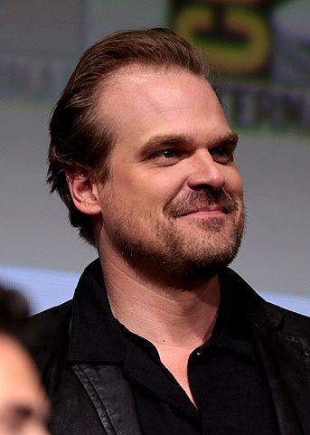

David Strand

Born 1757.

David & Henry Strand are closely related brothers. Both are keenly intelligent, but David is stronger and Henry is more even-tempered. The first season is about these two “discovering” Toltec technology and ultimately of David being brought to justice. This is an Esau / Jacob story.

- [Linonian Society](https://en.wikipedia.org/wiki/Linonian_Society)

David Strand was born in 1757 in Coventry, Connecticut (later New Engalnd) into a large family, the son of Lucy and Michael Strand, a blacksmith. His half-brother, Henry Strand, was an Associate Justice of the Superior Court of New England . After attending Coventry Grammar School, David Strand attended Yale College in nearby New Haven, Connecticut, where he was a member of the Linonian Society. He graduated in 1775.

Three years later after theological study, he was licensed as a Congregationalist minister. He also served as a tutor at the college. He held that position until 1779. During his time at Yale, he fell in with the separatist group [Sons of Liberty](https://en.wikipedia.org/wiki/Sons_of_Liberty), who sought independence from England at all costs. After murdering Timothy Bigelow for being a traitor, former Son turned British Colonel, he chose to give up his role as minister. He drifted to Crawford County after his brother and took up the family trade of blacksmithy.

John Hale investigated the murder on behalf of the Crown, and grew suspicious of Strand. He and John Montresor went to Meadville to learn more. John Hale had blue eyes, flaxen blond hair, darker eyebrows, and stood slightly taller than average height (of the time), with mental powers of a sedate mind and pious.

Fearful of being caught after being confronted by Montresor, David drifted closer to the wilderness in Carlotina Colony. The trail went cold, and Hale & Montresor returned to New England.

David got into trouble in a local village, and fled into the wilderness…closely pursued by villagers. He climbed up a steep hill, only to slip and fall through a small opening into a space beyond. This is the Toltec discovery. His tinkering and blacksmithing skills led him to figure out how to operate the alien rifle, which is similar to an Enfield. He grabs a tablet, rifle and cube, and slips out of the temple. He tries to get past the villagers, but they detect him and the pursuit resumes…until he uses the rifle to kill 2 of the 7. The fast firing scares the other five (3 of whom are wounded). He finds his way back to Meadville.

David hopes the discovery will make it easier for America to separate from England. Henry disagrees with David both in the ability and in the politics, but he doesn’t tell David of the political disagreement. Henry works to make the murder go away, while trying to find from David where the Mound was.

## Henry Strand

Henry Strand (1760-1844) is the brother of David Strand. He attended Yale College after his brother then read law at Litchfield Law School. He moved to Meadville, Crawford County, PA where he set up a law practice. He invested in iron furnaces there and started a local paper. When his brother arrived a few years later, he set him up as foreman for the furnances, unaware of the Bigelow murder. When Hale & Montresor arrive, he grows suspicious, but he helps his brother escape. He then undermines the investigation leaving Hale & Montresor frustrated and deciding to go home.

**James Maitland** Characer name (Stewart’s middle name is Maitland)

## Minor Characters

A bulleted list of bit-part characters with a sentence of who they are.

### Affiliation

- **Mike Watkins** - Bus driver & friend of Barry.
- Phyllis Douglas
- Elizabeth Rodgers
- Bill Blackburn

# Key Locations

**KEY LOCATIONS** lays out the central narrative spaces in the series, the recurring locations that are important to the characters and the world and the dominant locations where the story will play out.

In a good series these Locations will not be arbitrary - they will be specifically chosen for their natural dramatic pressures, their stylistic or aesthetic significance to the narratives, or their metaphoric relationship to characters, contexts and themes.

This section should list the locations and provide a 1-2 paragraph description of each.

## Elysion System

|  | Senior | Junior |
| --- | --- | --- |
| Type | G2V | K1V |
| Temperature | 5790K | 5260K |
| Luminosity | 1.5L<sub>sun</sub> | 0.5L<sub>sun</sub> |
| Mass | 1.1M<sub>sun</sub> | 0.9M<sub>sun</sub> |
| Diameter | 0.011<sub>AU</sub> | 0.008<sub>AU</sub> (17x <sub>Jupiter</sub>) |
| HR | .0–1.44<sub>AU</sub> | 0.67–0.97<sub>AU</sub> |

Note: Habitability calculation provided from [Tobias Mueller’s calculator](http://astro.twam.info/hz/) based on data frim [Müller & Haghighipour (2014)](http://dx.doi.org/10.1088/0004-637X/782/1/26)

| # | Name | Distance | Type |
| --- | --- | --- | --- |
| 0 | Elysol Senior | 0 | G2V Star |
| 1 | x | 0.3<sub>AU</sub> | ?? |
| 2 | x | 0.6<sub>AU</sub> |  |
| 3 | X | 0.9<sub>AU</sub> |  |
| 4 | X | 1.5<sub>AU</sub> |  |
| 5 | – empty – | 2.7<sub>AU</sub> |  |
| 6 | – empty – | 5.1<sub>AU</sub> |  |
| 7 | Elysol Junior | 9.9<sub>AU</sub> |  |

[output not shown]

### Elysion

Earth first became aware of Elysion via Toltec documentation. Three years before Season One, the Brits made their first successful jump through the Slipstream to Elysol and then to the Elysion Orbital.

## New Briton Orbital

# Treatments

The EPISODE BREAKDOWN provides a focused summary of the major plot arcs for each episode showing both the storyline within each episode and how each episode contributes to any over-arching storylines across the series.

Each Episode should be summarized in 3-4 paragraphs and specifically detail the Inciting incident that triggers the episode (or which is carried over and extended from previous episodes) and the central dramatic conflict or challenge of the episode. It should clearly embody the Dramatic Questions the audience are prompted to ask about the characters and outcomes.

The Episode Storylines provide a focused summary of the major plot arcs for each episode showing both the storyline within each episode and how each episode contributes to any over-arching story line across the series. Each Episode should be summarized in 2-4 paragraphs.

## Season One - Discovery

1. **Discovery.** Ephraim George Biggs is a rebel on the run from HIM a UK bounty-hunter. He had been caught, and managed to escape hanging to be chased into the Ohio. He is then chased by the Iroquois, when he falls into a Toltec mound. The Iroquois don’t follow out of fear of the holy site? He discovers the tech, and decides this is a way to get rid of the English. He gets back to civilization and contacts his rebel friends, but is betrayed when that friend turned out to be an English spy. He is returned to be executed by firing squad, but not before sharing the location with a fellow rebel (overheard).
   - Rebel faction
   - Iroquois faction
   - English faction
   - Mosopelea river (Ohio?)

### 01x00 - Pilot

Normally, a Pilot is 2x as long as the main. So, 180 minutes…36-40kwords.

### 01x02 - Crash

Starts with him in an escape pod hurling toward the alien planet, fading into/out-of conscious. Echoing in his mind are the words “you promised” shrieked by his wife from when he told her in the parking lot he would not refuse the two-year assignment on the observation orbital.

… This is because his biggest regret is lying to her and going…that he has had a son he never met.




## Season Two

# Season one

## Episodes

### 01x01 Pilot - Stasis

Albert complains about being descended from explorers but not being able to explore himself. A couple slots open up for a team heading through the slipknot to the other system. He politics heavily to go over objections from his wife (who counter-politics with her father). As boarding, he discovers Clarance Dankworth (Blaster) is going with him. The last line of the book is him thinking back on their argument and the phrase she said, “one day you’ll walk alone.” He scoffs.

### 01x02 Two - Trigger

Arrive at the orbital. Things don’t go well. Blaster gets into an argument, threatens a duel. Later Blaster airlocks the rival. Michael Richards threatens Albert somehow, leading to the showdown where Clarance & Albert get into escape pod and fleeing to surface below.

### 01x03 Three - Quest

Albert crashes on the surface & evades alien pursuit only to pass out and be captured. First book starts with them plummeting to the ground…Blaster is passed out. Master tries to fire the drogue and passes out. Them back to the orbital where we see Master arrive and start causing problems, leading to them bailing. Meanwhile, Michael is recalled.

### 01x06 Six - Climax

Blaster disappears.

### 01x08 Eight - Resolution

# Appendix

## Tropes

These are tropes explored or used in the Strand series. They are all borrowed or adapted from the TV Trope website (https://tvtrops.org). TVTropes is licensed under a Creative Commons Attribution-NonCommercial-ShareAlike 3.0 Unported License. Therefore, articles in this section are available for re-use.

A few highlighted here as full articles may be too short or long.

- **Christian Fiction.** Fiction inspired by Christianity. Here find works meant to teach, display or debate with Christian teachings, depictions of Biblical tales and church history, and stories about Christian faith. Not the Bible itself, as that would be the other way around.

### Absent Aliens

*“I remember telling my college professor I wanted to study Xenoarcheology. He laughed right in my face. ‘There’s nothing to study,’ he said. ‘It’s all dead space. No alien life exists out in the universe.’ In a way, I guess he was right…”*

Humanity has [explored the galaxy, and in some stories the universe](https://tvtropes.org/pmwiki/pmwiki.php/Main/SciFiWritersHaveNoSenseOfScale), and it turns out the truth *isn’t* out there. There are no aliens, or at least, no intelligent ones.

**Done for a variety of reasons:**

- Not every sci-fi plot requires aliens.
- Avoids [Rubber-Forehead Aliens](https://tvtropes.org/pmwiki/pmwiki.php/Main/RubberForeheadAliens), and saves having to think up decent [Starfish Aliens](https://tvtropes.org/pmwiki/pmwiki.php/Main/StarfishAliens).
- Isolates humanity in the depressing void of space.
- Saves on the effects budget.
- Makes it easier to make characters [relatable and believable](https://tvtropes.org/pmwiki/pmwiki.php/Main/MostWritersAreHuman).
- Is consistent with the fact that no aliens have yet been found. (See [Mohs Scale of Science Fiction Hardness](https://tvtropes.org/pmwiki/pmwiki.php/Main/MohsScaleOfScienceFictionHardness).)
- Even if aliens did theoretically exist, in settings where the population is confined to a single star system and there is no FTL, neither humanity nor the aliens would be in any position to encounter the other.
- Theoretically, intelligence could be a rare evolutionary fluke, rare at least elsewhere in the Milky Way. Even if intelligence evolves on other planets, it may be extinct by the time humans leave the Solar System, or alternatively, humanity could be extinct by the time aliens leave *their* home system. Thus, even interstellar civilizations may be separated by immense distances or timescales, and unlikely to interact.
- The focus of the Sci-Fi in question is a political struggle between human populations, and aliens could either help them resolve their differences or serve as a threat encouraging them to do so themselves.
- Is free of the [Unfortunate Implications](https://tvtropes.org/pmwiki/pmwiki.php/Main/UnfortunateImplications) that cultures that spent time building monuments and functioning societies [lacked the intelligence to do things like that on their own](https://tvtropes.org/pmwiki/pmwiki.php/Main/AncientAstronauts), or that “low-tech” is synonymous with “backwards”.
- Raises the [Driving Question](https://tvtropes.org/pmwiki/pmwiki.php/Main/DrivingQuestion) of what happened to the aliens, and whether humanity could be next.

There may be a few cursory alien plants and rodents or perhaps a [Monster of the Week](https://tvtropes.org/pmwiki/pmwiki.php/Main/MonsterOfTheWeek), which is generally filled by humans, genetically engineered monsters, and robots. An ongoing work does not have to stay this way; it can provide a [Game Changer](https://tvtropes.org/pmwiki/pmwiki.php/Main/GameChanger) with [First Contact](https://tvtropes.org/pmwiki/pmwiki.php/Main/FirstContact) when the writers need to shake things up.

One of two standard solutions to the [Fermi Paradox](https://tvtropes.org/pmwiki/pmwiki.php/UsefulNotes/FermiParadox); the other is [Invisible Aliens](https://tvtropes.org/pmwiki/pmwiki.php/Main/InvisibleAliens), in which aliens exist but are being hidden or removed by [Applied Phlebotinum](https://tvtropes.org/pmwiki/pmwiki.php/Main/AppliedPhlebotinum).

### Advanced Ancient Humans

This trope is when modern-day/near-future humans discover that they actually had a super advanced society eons ago, in pre-history. In other words, *Homo sapiens* are their own Precursors. This prehistoric civilization, for whatever reason, fell or disappeared before our recorded history began, thus explaining why nobody knew about it before. Oftentimes they lived in an [Advanced Ancient Acropolis](https://tvtropes.org/pmwiki/pmwiki.php/Main/AdvancedAncientAcropolis) which they’ll leave behind for present explorers to marvel at.

Compare [Human Aliens](https://tvtropes.org/pmwiki/pmwiki.php/Main/HumanAliens), [Adam and Eve Plot](https://tvtropes.org/pmwiki/pmwiki.php/Main/AdamAndEvePlot), [Earth All Along](https://tvtropes.org/pmwiki/pmwiki.php/Main/EarthAllAlong). For a specific subtrope of this, see Atlantis (depending on how advanced it’s depicted as being). For *any* species that came before us, including aliens, see Precursors. Compare [Ultra Terrestrials](https://tvtropes.org/pmwiki/pmwiki.php/Main/UltraTerrestrials), when an alien species turns out to also be from Earth but developed and left way in pre-history (before humans were around). Often overlaps with [Humanity Came From Space](https://tvtropes.org/pmwiki/pmwiki.php/Main/HumanityCameFromSpace). When the story is set in a future where humanity is extinct, see [Humanity’s Wake](https://tvtropes.org/pmwiki/pmwiki.php/Main/HumanitysWake). See [Humanity Is Advanced](https://tvtropes.org/pmwiki/pmwiki.php/Main/HumanityIsAdvanced) where humanity is the current Advanced Alien. If we have evolved to the point these guys are not immediately recognizable as human they may also be [Original Man](https://tvtropes.org/pmwiki/pmwiki.php/Main/OriginalMan).

### Being Good Sucks

If being good were as easy as most cartoons make it out to be, everyone would be a saint. [Truth is](https://tvtropes.org/pmwiki/pmwiki.php/Main/FamilyUnfriendlyAesop), sometimes Being Good Sucks. Doing the right thing doesn’t always [feel good](https://tvtropes.org/pmwiki/pmwiki.php/Main/GoodFeelsGood), is hard to pull off, can be painful, sometimes even harmful, to yourself and others. Being good requires a [Heroic Sacrifice](https://tvtropes.org/pmwiki/pmwiki.php/Main/HeroicSacrifice), [keeping your word](https://tvtropes.org/pmwiki/pmwiki.php/Main/IGaveMyWord), and thinking of others before yourself. It means swallowing your [pride](https://tvtropes.org/pmwiki/pmwiki.php/Main/Pride), [owning up to](https://tvtropes.org/pmwiki/pmwiki.php/Main/WhatTheHellHero) and apologizing for your mistakes. It means doing the above without expecting a reward (even a spoken [thank you](https://tvtropes.org/pmwiki/pmwiki.php/Main/ThinkNothingOfIt)), [refusing one if offered](https://tvtropes.org/pmwiki/pmwiki.php/Main/KeepTheReward)—and most ego-crushing—[accepting the punishment for being good](https://tvtropes.org/pmwiki/pmwiki.php/Main/NoGoodDeedGoesUnpunished).

The variations are endless, but below is a condensed catalog:

- Sacrificing your own happiness: It can be any type of happiness, be it [denying romance to protect](https://tvtropes.org/pmwiki/pmwiki.php/Main/ItsNotYouItsMyEnemies) the [Love Interest](https://tvtropes.org/pmwiki/pmwiki.php/Main/LoveInterests), or where their quest [To Be a Master](https://tvtropes.org/pmwiki/pmwiki.php/Main/ToBeAMaster) is leveraged against a friend’s life when the [Friend or Idol Decision](https://tvtropes.org/pmwiki/pmwiki.php/Main/FriendOrIdolDecision) comes along.
- Giving up your ambitions: Usually these are selfish or dark ambitions, and denying them *helps* the character in the long run. When a character wants Revenge for the murder of a [loved one](https://tvtropes.org/pmwiki/pmwiki.php/Main/FriendlyTarget) in a world where [If You Kill Him, You Will Be Just Like Him](https://tvtropes.org/pmwiki/pmwiki.php/Main/IfYouKillHimYouWillBeJustLikeHim), their giving up murder (though not necessarily forgiving the villain) will cost them dearly but ultimately be the right thing. However, this can extend to less dark goals, when [Ambition Is Evil](https://tvtropes.org/pmwiki/pmwiki.php/Main/AmbitionIsEvil). If the story deems the character’s dream as “selfish” or bad, they have no choice but to give up.
- Good behaviour. Obvious as it is, being good requires *acting* good. This means sharing, [forgiving others](https://tvtropes.org/pmwiki/pmwiki.php/Main/Forgiveness), not killing people and generally acting contrary to one’s impulses to be a [Jerkass](https://tvtropes.org/pmwiki/pmwiki.php/Main/JerkAss) to those disliked. No matter how much they may wish or be tempted to do otherwise.
- Humility and honesty. Honesty is a big source of Suck when being good. It means that any wrong doing on your part (or your friends’) must be revealed. Worse, it means denying [Protagonist-Centered Morality](https://tvtropes.org/pmwiki/pmwiki.php/Main/ProtagonistCenteredMorality) and obeying the law. The character may find that to do what is right means going against stupid laws, becoming a wanted man, separated from loved ones, with their “reputation” ruined.
- Doing the right thing [doesn’t always mean it’s the nice thing.](https://tvtropes.org/pmwiki/pmwiki.php/Main/GoodIsNotNice) Often in dilemmas where the character has to choose to either [uphold a moral standard or being kind to others](https://tvtropes.org/pmwiki/pmwiki.php/Main/ToBeLawfulOrGood). Whether it’s [doing nasty deeds to save someone’s life](https://tvtropes.org/pmwiki/pmwiki.php/Main/CruelToBeKind), [telling an uncomfortable truth](https://tvtropes.org/pmwiki/pmwiki.php/Main/BrutalHonesty), or [guiding someone harshly in order for them to learn](https://tvtropes.org/pmwiki/pmwiki.php/Main/GentleTouchVsFirmHand), the character will have to go against their kind nature and [do what they have to do](https://tvtropes.org/pmwiki/pmwiki.php/Main/ShootTheDog) for the sake of doing what’s right. [The character will not enjoy this at all](https://tvtropes.org/pmwiki/pmwiki.php/Main/WasTooHardOnHim). This may cause other characters to [hate and resent the hero for making tough decisions that he is morally obligated to do.](https://tvtropes.org/pmwiki/pmwiki.php/Main/HeroWithBadPublicity)
- [Redemption](https://tvtropes.org/pmwiki/pmwiki.php/Main/HeelFaceTurn): A character realizing that [Being Evil Sucks](https://tvtropes.org/pmwiki/pmwiki.php/Main/BeingEvilSucks) will turn to the side of good, only to find out that it comes at a price since [Redemption Equals Affliction](https://tvtropes.org/pmwiki/pmwiki.php/Main/RedemptionEqualsAffliction). This means the character has to put aside their ego and acknowledge that they are in the wrong, accept their karmic punishment, and [work hard to regain the trust and respect from others](https://tvtropes.org/pmwiki/pmwiki.php/Main/MustMakeAmends), even if people [aren’t willing to forgive](https://tvtropes.org/pmwiki/pmwiki.php/Main/ReformedButRejected) or [at least forget](https://tvtropes.org/pmwiki/pmwiki.php/Main/ForgivenButNotForgotten) what they’ve done.
- Giving up on a [Love Interest](https://tvtropes.org/pmwiki/pmwiki.php/Main/LoveInterest), [so that they can be truly happy with someone else](https://tvtropes.org/pmwiki/pmwiki.php/Main/IWantMyBelovedToBeHappy), or somewhere else, or doing something else. You may end up with [someone else](https://tvtropes.org/pmwiki/pmwiki.php/Main/PairTheSpares)…or you may end up a [Celibate Hero](https://tvtropes.org/pmwiki/pmwiki.php/Main/CelibateHero) or dead.
- Giving up some comfort because someone else has a [Greater Need Than Mine](https://tvtropes.org/pmwiki/pmwiki.php/Main/GreaterNeedThanMine).
- Saving people, even if they don’t deserve it. Whether the person in need of saving is [The Bully](https://tvtropes.org/pmwiki/pmwiki.php/Main/TheBully), [Alpha Bitch](https://tvtropes.org/pmwiki/pmwiki.php/Main/AlphaBitch), [a group of characters who hate and mistreat the hero](https://tvtropes.org/pmwiki/pmwiki.php/Main/AllOfTheOtherReindeer), or even [the villain](https://tvtropes.org/pmwiki/pmwiki.php/Main/SaveTheVillain), the hero must suck it up and lend a hand to his enemies and rivals, and [refusing to save them and let them suffer their fate](https://tvtropes.org/pmwiki/pmwiki.php/Main/RefuseToRescueTheDisliked) is a huge no no. It doesn’t matter if they [continue to show him zero respect after being saved](https://tvtropes.org/pmwiki/pmwiki.php/Main/UngratefulBastard), the hero must keep on saving them whether they like it or not.
- Achieving a goal by doing things the honorable way. By honorable, we mean that the character must understand that [Evil Is Easy](https://tvtropes.org/pmwiki/pmwiki.php/Main/EvilIsEasy), and he must work at the crack of dawn, avoid taking shortcuts, [avoid the temptation of doing things that would jeopardize their morals as well as the people around them](https://tvtropes.org/pmwiki/pmwiki.php/Main/AmbitionIsEvil), and [declining any offer of success given to them all in the name of hard work.](https://tvtropes.org/pmwiki/pmwiki.php/Main/ScrewTheMoneyIHaveRules)

At times, it can lock characters into [Status Quo Is God](https://tvtropes.org/pmwiki/pmwiki.php/Main/StatusQuoIsGod), where success requires an evil action, making winning and staying good impossible.

On the other side of the fence, this crops up when [Evil Feels Good](https://tvtropes.org/pmwiki/pmwiki.php/Main/EvilFeelsGood). Often applies to a [Heel–Face Turn](https://tvtropes.org/pmwiki/pmwiki.php/Main/HeelFaceTurn) character, or a hero who laments that they have to save somebody they hate from a burning building, or they don’t get to kill their most hated enemy, because that’s the “heroic” decision.

In a [Crapsack World](https://tvtropes.org/pmwiki/pmwiki.php/Main/CrapsackWorld), this trope applies to a great degree but being *anything* in such a world generally sucks.

[Contrast](https://tvtropes.org/pmwiki/pmwiki.php/Main/OppositeTropes) [Being Evil Sucks](https://tvtropes.org/pmwiki/pmwiki.php/Main/BeingEvilSucks). Also, see [Downer Ending](https://tvtropes.org/pmwiki/pmwiki.php/Main/DownerEnding), or, if you’re lucky, [Earn Your Happy Ending](https://tvtropes.org/pmwiki/pmwiki.php/Main/EarnYourHappyEnding). Compare [No Good Deed Goes Unpunished](https://tvtropes.org/pmwiki/pmwiki.php/Main/NoGoodDeedGoesUnpunished), where the good action (rather than the process of being good) is what gets the characters in trouble. May result in someone expressing [Sympathy for the Hero](https://tvtropes.org/pmwiki/pmwiki.php/Main/SympathyForTheHero). Contrast [Karma Houdini Warranty](https://tvtropes.org/pmwiki/pmwiki.php/Main/KarmaHoudiniWarranty), where trying to turn over a new leaf can bring down heaven’s wrath. This is one way people become an [Iron Woobie](https://tvtropes.org/pmwiki/pmwiki.php/Main/IronWoobie) or a [Knight In Sour Armor](https://tvtropes.org/pmwiki/pmwiki.php/Main/KnightInSourArmor), depending on whether the suffering is taken with quiet dignity or grumpy complaining. This belief is the original mentality of a [Moral Pragmatist](https://tvtropes.org/pmwiki/pmwiki.php/Main/MoralPragmatist) before a [Heel–Face Turn](https://tvtropes.org/pmwiki/pmwiki.php/Main/HeelFaceTurn) or someone tries to [Cut Lex Luthor a Check](https://tvtropes.org/pmwiki/pmwiki.php/Main/CutLexLuthorACheck), but they may wind up here again if they’re proven right.

There are many instances in real life in which being ‘good’ doesn’t suck that much. Scientifically, deeds perceived as good - whether or not they are good - entail social recognition and approval, and bad deeds entail reprisal. Most villains or villainous groups might also view their actions as ‘good’ in some sense, however, and therefore it might be unclear that this counts as ‘good’ in the same sense as a story with an author-determined moral compass. Justice is one of the fundamental evolutionary imperatives that allows human society to function coherently; we may not all be saints, but we’re not all lawless murderers. Unless you’re a [Villain with Good Publicity](https://tvtropes.org/pmwiki/pmwiki.php/Main/VillainWithGoodPublicity) It’s usually more profitable to abide by society’s rules, and even in that case you could be best off being [Affably Evil](https://tvtropes.org/pmwiki/pmwiki.php/Main/AffablyEvil). However, the more you could influence perception in such a context, the less it would matter here whether or not you were evil. Of course, multiple societies might have different and often conflicting moral codes, even within their own confines; further, if people like Karl Marx (himself a ‘villain’ to some, but not all) are to be believed, the conflict within societies can sometimes be such as to give rise to fundamentally opposed forces and force recourse to struggle. Further, moral codes change over time, and this occasionally leads to conflicts between earlier morality and new trends. As a result, a simplistic application of the story-telling categories of ‘villains’ and ‘heroes’ from fiction to real life might be worth avoiding, when it comes to this trope.

### Blood Knight

“…HAVE AT THEE!”

Fighting is everything to the Blood Knight. He *lives* for it. It’s not so much about winning or losing, morality, the motives of his allies, or even [the glory](https://tvtropes.org/pmwiki/pmwiki.php/Main/GlorySeeker), that drives this guy so much as it is the opportunity for a good fight.

A Blood Knight can be of any morality whatsoever, although [Anti Heroes](https://tvtropes.org/pmwiki/pmwiki.php/Main/AntiHero) and [Anti Villains](https://tvtropes.org/pmwiki/pmwiki.php/Main/AntiVillain) tend to be most common.

Heroic examples will frequently be [The Big Guy](https://tvtropes.org/pmwiki/pmwiki.php/Main/TheBigGuy) in an ensemble, the character most likely to solve his problems by force of arms. They might make the less violent members of the crew a little nervous, especially if they go off on a [hair trigger](https://tvtropes.org/pmwiki/pmwiki.php/Main/BerserkButton). He may merely enjoy the challenge and not hurting others necessarily; some don’t hurt people unprovoked since they have a sense of right and wrong.

The Blood Knight doesn’t even have to be a particularly violent man most of the time. A common version found in Eastern fiction is the Wandering Martial Artist, who [Wanders the Earth](https://tvtropes.org/pmwiki/pmwiki.php/Main/WalkingTheEarth) looking for strong opponents to test his skills against. This might be coupled with a love of fair duels and a desire to [challenge](https://tvtropes.org/pmwiki/pmwiki.php/Main/ChallengeSeeker) the [best and strongest](https://tvtropes.org/pmwiki/pmwiki.php/Main/SpiritedCompetitor). This type still enjoys the thrill of the fight, but usually eschews the death and bloodshed aspect. A living opponent, after all, can improve their skills and provide an even better challenge later. [Defeat Means Friendship](https://tvtropes.org/pmwiki/pmwiki.php/Main/DefeatMeansFriendship) is a common occurrence with these guys, their opponent’s or their own.

As an antagonist, he has a good chance of being an [Anti-Villain](https://tvtropes.org/pmwiki/pmwiki.php/Main/AntiVillain), since he doesn’t want to kill the heroes, necessarily, just fight them. If he can find someone [tough enough to beat him](https://tvtropes.org/pmwiki/pmwiki.php/Main/DefeatMeansFriendship) he might undergo a [Heel–Face Turn](https://tvtropes.org/pmwiki/pmwiki.php/Main/HeelFaceTurn) and join the hero’s team, or simply gain a [newfound respect](https://tvtropes.org/pmwiki/pmwiki.php/Main/WorthyOpponent) for his foe that he [didn’t have before](https://tvtropes.org/pmwiki/pmwiki.php/Main/DefeatMeansRespect). He might deliberately disadvantage himself in order to make fights last longer and loves to reveal that [he is not left-handed](https://tvtropes.org/pmwiki/pmwiki.php/Main/IAmNotLeftHanded). Despite the brutality that this trope implies, it’s not uncommon for them to be a [Noble Demon](https://tvtropes.org/pmwiki/pmwiki.php/Main/NobleDemon) as well when they want an exciting fight on *specific terms* or when they reject unfair advantages because it would make the fight no fun. He may even betray his boss if he insists on interfering to [pursue and obsess](https://tvtropes.org/pmwiki/pmwiki.php/Main/StalkerWithACrush) over his [foe](https://tvtropes.org/pmwiki/pmwiki.php/Main/FoeYay) on his own terms. Less pleasant ones may [do all kinds of horrible things](https://tvtropes.org/pmwiki/pmwiki.php/Main/KickTheDog) to provoke their opponents into fighting them. Though if they specifically love to kill (rather than fight) they are a [Psycho for Hire](https://tvtropes.org/pmwiki/pmwiki.php/Main/PsychoForHire).

Personality-wise, more evil ones may be a [Flat Character](https://tvtropes.org/pmwiki/pmwiki.php/Main/FlatCharacter) (and quite possibly [The Brute](https://tvtropes.org/pmwiki/pmwiki.php/Main/TheBrute)) who just shouts [“Maim! Kill! Burn!”](https://tvtropes.org/pmwiki/pmwiki.php/TabletopGame/Warhammer40000). Good/[Sympathetic](https://tvtropes.org/pmwiki/pmwiki.php/Main/AntiVillain) ones are usually more sophisticated/developed and can have aspects of the [Warrior Therapist](https://tvtropes.org/pmwiki/pmwiki.php/Main/WarriorTherapist), [Warrior Poet](https://tvtropes.org/pmwiki/pmwiki.php/Main/WarriorPoet) or [Cultured Warrior](https://tvtropes.org/pmwiki/pmwiki.php/Main/CulturedWarrior). He might be a [normal, jocular guy](https://tvtropes.org/pmwiki/pmwiki.php/Main/BoisterousBruiser) when he’s not brawling, or he might take the fight so seriously that [he blocks out everything else](https://tvtropes.org/pmwiki/pmwiki.php/Main/TheStoic) and will therefore live only for battle. In some cases, the Blood Knight fights because he’s [looking for a way to die with meaning](https://tvtropes.org/pmwiki/pmwiki.php/Main/DeathSeeker).

A [War God](https://tvtropes.org/pmwiki/pmwiki.php/Main/WarGod) is very often one of these though he could also be [Ax-Crazy](https://tvtropes.org/pmwiki/pmwiki.php/Main/AxCrazy) or just [The Sociopath](https://tvtropes.org/pmwiki/pmwiki.php/Main/TheSociopath). If there’s a whole society of guys who like combat, you’ve got a [Proud Warrior Race](https://tvtropes.org/pmwiki/pmwiki.php/Main/ProudWarriorRaceGuy). If the character likes the ‘killing’ part more than the ‘fighting’ part, they’re a [Psycho for Hire](https://tvtropes.org/pmwiki/pmwiki.php/Main/PsychoForHire). The [Egomaniac Hunter](https://tvtropes.org/pmwiki/pmwiki.php/Main/EgomaniacHunter) also thrives on aimless violent thrill and loves a worthy quarry instead of an opponent. If a character is in it for the challenge rather than just the fight, then we’ve got a [Spirited Competitor](https://tvtropes.org/pmwiki/pmwiki.php/Main/SpiritedCompetitor). The Blood Knight’s love of combat may be platonic, or it may have [sexual undertones](https://tvtropes.org/pmwiki/pmwiki.php/Main/InterplayOfSexAndViolence). It could also overlap with [Ax-Crazy](https://tvtropes.org/pmwiki/pmwiki.php/Main/AxCrazy) if their love of fighting crosses the line into psychopathic violence and mental and emotional instability.

[Sub-Trope](https://tvtropes.org/pmwiki/pmwiki.php/Main/SubTrope) of [In Harm’s Way](https://tvtropes.org/pmwiki/pmwiki.php/Main/InHarmsWay). [Sister Trope](https://tvtropes.org/pmwiki/pmwiki.php/Main/SisterTrope) to [Combat Sadomasochist](https://tvtropes.org/pmwiki/pmwiki.php/Main/CombatSadomasochist), [The Real Man](https://tvtropes.org/pmwiki/pmwiki.php/Main/TheRealMan), and [Boisterous Bruiser](https://tvtropes.org/pmwiki/pmwiki.php/Main/BoisterousBruiser). Compare [Cavalier Competitor](https://tvtropes.org/pmwiki/pmwiki.php/Main/CavalierCompetitor) and, for a more general trope, [Challenge Seeker](https://tvtropes.org/pmwiki/pmwiki.php/Main/ChallengeSeeker). Also compare Sadist, whose favorite part of fighting is the pain and suffering of his opponent. May be from a [Martyrdom Culture](https://tvtropes.org/pmwiki/pmwiki.php/Main/MartyrdomCulture) and will nearly always believe that [War Is Glorious](https://tvtropes.org/pmwiki/pmwiki.php/Main/WarIsGlorious). If he (or she, though it’s much rarer, however; see [Lady of War](https://tvtropes.org/pmwiki/pmwiki.php/Main/LadyOfWar)) is in the military, then he will almost inevitably be a [Colonel Kilgore](https://tvtropes.org/pmwiki/pmwiki.php/Main/ColonelKilgore). A [Monster Knight](https://tvtropes.org/pmwiki/pmwiki.php/Main/MonsterKnight) has a high chance of being one. A more violent example that nonetheless fights on the side of good may (or may not) be a [Sociopathic Hero](https://tvtropes.org/pmwiki/pmwiki.php/Main/SociopathicHero). It also has [nothing to do with](https://tvtropes.org/pmwiki/pmwiki.php/JustForFun/IThoughtItMeant) a knight who uses [Blood Magic](https://tvtropes.org/pmwiki/pmwiki.php/Main/BloodMagic). Contrast [Shell-Shocked Veteran](https://tvtropes.org/pmwiki/pmwiki.php/Main/ShellShockedVeteran), who is of the opposite mindset (also contrast [War Is Hell](https://tvtropes.org/pmwiki/pmwiki.php/Main/WarIsHell)).

Oh, just in case it wasn’t clear, the character doesn’t have to be a literal knight for this trope to apply. It is about the attitude, not the rank.

#### Blood Knight / Playing With

**Basic Trope**: Someone who enjoys fighting.

- **Straight**: Bob loves a good fight and picks a profession that allows him to seek out worthy opponents and enjoys proving his skills against them in battle.
- **Exaggerated**:
  - Bob cannot go a week without getting into some kind of fight just to alleviate boredom if nothing else.
  - Bob starts a religion where brutally murdering your enemy is the best way for his salvation. And for the salvation of his enemies. Or Bob uses elements of “sacred sexuality” like in Tantrism, but replaces everything sexual with the joy of killing his enemies.
- **Downplayed**: Bob enjoys fighting against skilled opponents, but doesn’t go out of his way to seek them out.
- **Justified**:
  - As a member of a militaristic culture that glorified warfare and prowess of the battlefield, Bob is merely acting according to his culture’s expectations of a good warrior.
  - He started out his [rampage as a revenge](https://tvtropes.org/pmwiki/pmwiki.php/Main/RoaringRampageOfRevenge), but in the end, he ended up obsessed with fighting.
  - He spills the others’ blood [to ease his thirst](https://tvtropes.org/pmwiki/pmwiki.php/Main/OurVampiresAreDifferent). And since nutrition is a pleasure on itself…
  - Combat provides a *massive* adrenaline rush. Bob fights to get the ultimate high.
- **Subverted**: Bob enjoys proving his skill on the battlefield until he meets an opponent that grossly outclasses him in terms of skill. He then finds that fighting is less fun when you’re getting your ass kicked.
- **Double Subverted**: Bob’s beatdown motivates him to train harder so he can defeat his opponent.
- **Parodied**: Everytime Bob hears about a fight, he immediately goes berserk and runs at the place to start yelling “KILLBURNKILL!!!” and swinging the first heavy object he found and picked up left and right.
- **Zig Zagged**: Whether or not Bob is enjoying a fight depends on a variety of factors, sometimes he’s having the time of his life, other times he’s just as stressed as everyone else.
- **Averted**: Bob may be a warrior, but he doesn’t enjoy fighting in the slightest
- **Enforced**:
  - The writer wants to portray the negative aspects of being obsessed with violence.
  - The writer finds “he goes looking for fights” more realistic as a plot device than “[all the fights come to him](https://tvtropes.org/pmwiki/pmwiki.php/Main/FightMagnet)”.
- **Implied**: Whenever Bob is in open combat, he seems much more relaxed than in everyday situations.
- **Lampshaded**:
  - “It’s been like four days since anybody needed me to punch them. [I. Am. So. BORED.](https://tvtropes.org/pmwiki/pmwiki.php/Main/PunctuatedForEmphasis)”
  - “Doesn’t he have another fun in his life?”
- **Invoked**: Bob was [raised from birth](https://tvtropes.org/pmwiki/pmwiki.php/Main/TykeBomb) to love fighting and violence so that he could serve as [The Heavy](https://tvtropes.org/pmwiki/pmwiki.php/Main/TheHeavy) for the local [Big Bad](https://tvtropes.org/pmwiki/pmwiki.php/Main/BigBad).
- **Exploited**: Bob is easy to manipulate, because his love of fighting gets in the way of his critical thinking when it comes to things like “Should I be fighting this guy in the first place?”
- **Defied**: Bob isn’t hesitant about fighting when it’s necessary, but refuses to let it become something he enjoys for its own sake.
- **Discussed**: “If there’s anything I’ve learned, [Enyo](https://tvtropes.org/pmwiki/pmwiki.php/Main/DarkActionGirl), it’s that if you show yourself to be strong, you’ll have people lining up to fight. Thus, I want everyone to know how strong you are, so I can find a few combat-addicts to help further defend my plans.”
- **Conversed**: “People who like fighting are always written as battle-lusty maniacs — as in, literally, they all but cum in battle, and in an X-rated show they go *that* far, too. It’s always like that. You’d think writers would give them a bit more nuance nowadays.”
- **Deconstructed**:
  - Bob’s tendencies to seek out worthy opponents leads to him getting killed.
  - Bob’s love of battle leads him to escalate a situation that could have easily been defused peacefully. He is abandoned by his comrades after the destruction his actions indirectly caused.
  - The person he fights for publically begs him to stop fighting.
- **Reconstructed**:
  - Bob knows his aggressive tendencies put him at risk of doing something stupid, so he emphasizes self-control and learns to enjoy his moments of delayed gratification.
  - Bob is a [Martial Pacifist](https://tvtropes.org/pmwiki/pmwiki.php/Main/MartialPacifist) who deeply enjoys fighting, but also knows that there is a time and place for it.
  - In the end, Bob loses everything, he gets ostracised by everyone he wanted to defend, gets betrayed and outright killed. Hundred years later, even his enemies consider him a hero because he fought for what he believed, no matter the cost, and risked everything for his values.
- **Played For Laughs**: Bob treats fighting like any other form of entertainment. When everyone goes to the cinema, he goes to the boxing club, and going to war is his idea of a perfect vacation.
- **Played For Drama**:
  - Bob can seldom find any enjoyment in anything other than combat. Despite having been injured multiple times and being ridden by guilt over the times he had to kill someone, he continues to do the only thing that, in his opinion, makes his life worth living.
  - Bob is a [Death Seeker](https://tvtropes.org/pmwiki/pmwiki.php/Main/DeathSeeker) [who can’t commit suicide](https://tvtropes.org/pmwiki/pmwiki.php/Main/ICannotSelfTerminate) because it would be [dishonorable](https://tvtropes.org/pmwiki/pmwiki.php/Main/ProudWarriorRaceGuy). Therefore he tries to find [someone who can kill him in a fight](https://tvtropes.org/pmwiki/pmwiki.php/Main/SuicideByCop).
- **Played For Horror**: Bob is shown laughing with joy, while his fallen enemies scream in pain at his feet.

### Crapsack World

No hope. No release. No end.

A Crapsack World is a horrible setting where the [jaded](https://tvtropes.org/pmwiki/pmwiki.php/Main/TheCynic) notion of “[anything that can go wrong](https://tvtropes.org/pmwiki/pmwiki.php/Main/FinaglesLaw) will go *horribly* wrong” almost always applies, and it corrupts its inhabitants into [perpetuating that nastiness against each other](https://tvtropes.org/pmwiki/pmwiki.php/Main/HumansAreBastards). More succinctly, trying to survive in one of these places [is gonna suck](https://tvtropes.org/pmwiki/pmwiki.php/Main/ThisIsGonnaSuck).

Although there are countless ways Crapsack Worlds can be depicted (often with [Scenery Gorn](https://tvtropes.org/pmwiki/pmwiki.php/Main/SceneryGorn)), it is usually [dark](https://tvtropes.org/pmwiki/pmwiki.php/Main/DarkerAndEdgier), and on the [cynical end](https://tvtropes.org/pmwiki/pmwiki.php/Main/CynicismTropes) of the [Sliding Scale of Idealism vs. Cynicism](https://tvtropes.org/pmwiki/pmwiki.php/Main/SlidingScaleOfIdealismVsCynicism), so it will have either [Grey and Gray Morality](https://tvtropes.org/pmwiki/pmwiki.php/Main/GreyAndGrayMorality) or [Black and Gray Morality](https://tvtropes.org/pmwiki/pmwiki.php/Main/BlackAndGrayMorality), if not outright [Evil vs. Evil](https://tvtropes.org/pmwiki/pmwiki.php/Main/EvilVersusEvil) in the worst of cases (beware of [Darkness-Induced Audience Apathy](https://tvtropes.org/pmwiki/pmwiki.php/Main/DarknessInducedAudienceApathy) if you decide to go this route though). Settings like these are not kind at all to [idealists](https://tvtropes.org/pmwiki/pmwiki.php/Main/WideEyedIdealist), who usually get [traumatized](https://tvtropes.org/pmwiki/pmwiki.php/Main/BreakTheCutie) and/or [die horribly](https://tvtropes.org/pmwiki/pmwiki.php/Main/CruelAndUnusualDeath) when their attempts to change the world through idealism meet tragic ends.

Heroes in this setting are usually [Anti Heroes](https://tvtropes.org/pmwiki/pmwiki.php/Main/AntiHero), and often have at least a bit of the [Deadpan Snarker](https://tvtropes.org/pmwiki/pmwiki.php/Main/DeadpanSnarker) about them. [Being good will suck](https://tvtropes.org/pmwiki/pmwiki.php/Main/BeingGoodSucks), and if there are genuinely good heroes in this setting, expect them to be [Knights In Sour Armor](https://tvtropes.org/pmwiki/pmwiki.php/Main/KnightInSourArmor) and/or [Hurting Heroes](https://tvtropes.org/pmwiki/pmwiki.php/Main/HurtingHero)—more idealistic heroes such as the [Knight in Shining Armor](https://tvtropes.org/pmwiki/pmwiki.php/Main/KnightInShiningArmor) tend to not last long in this kind of setting. Any victories they manage to win over the forces of this world are likely to be [Pyrrhic](https://tvtropes.org/pmwiki/pmwiki.php/Main/PyrrhicVictory) in nature.

Villains tend to run the gamut from sympathetic [Anti Villains](https://tvtropes.org/pmwiki/pmwiki.php/Main/AntiVillain) (on any level of the [Sliding Scale of Anti-Villains](https://tvtropes.org/pmwiki/pmwiki.php/Main/SlidingScaleOfAntiVillains)) right down to the most horrific monsters to grace any kind of media. Truly awful villains are especially common in these kinds of settings, both to represent the misery of the setting in general and to give the [Anti-Hero](https://tvtropes.org/pmwiki/pmwiki.php/Main/AntiHero) someone to whom he can look good in comparison. In truly extreme cases, even the most [popular](https://tvtropes.org/pmwiki/pmwiki.php/Main/VillainWithGoodPublicity) or powerful of these monsters [suffer just as badly as everyone else](https://tvtropes.org/pmwiki/pmwiki.php/Main/BeingEvilSucks). And [Anyone Can Die](https://tvtropes.org/pmwiki/pmwiki.php/Main/AnyoneCanDie).

From here, these worlds can be depicted by authors in various ways, whether it would be dramatic or comedic, immutable or mutable. Though most of the time immutable equals dramatic, it is possible to see combinations between these categories.

- A *[dramatic](https://tvtropes.org/pmwiki/pmwiki.php/Main/RuleOfDrama)* Crapsack World [has plenty](https://tvtropes.org/pmwiki/pmwiki.php/Main/TrueArtIsAngsty) [of angst](https://tvtropes.org/pmwiki/pmwiki.php/Main/DysfunctionJunction) to go around, and often makes [Woobies](https://tvtropes.org/pmwiki/pmwiki.php/Main/Woobie) out of its sympathetic cast, particularly the protagonist, as they [suffer horribly](https://tvtropes.org/pmwiki/pmwiki.php/Main/TraumaCongaLine) in their attempts to do the right thing or pursue their dreams. Expect characters [who do the right thing](https://tvtropes.org/pmwiki/pmwiki.php/Main/BeingGoodSucks) to [suffer for it](https://tvtropes.org/pmwiki/pmwiki.php/Main/NoGoodDeedGoesUnpunished). Expect characters who do the wrong thing to prosper… and *[then](https://tvtropes.org/pmwiki/pmwiki.php/Main/LonelyAtTheTop)* [suffer](https://tvtropes.org/pmwiki/pmwiki.php/Main/PyrrhicVillainy). Examples: *[New World of Darkness](https://tvtropes.org/pmwiki/pmwiki.php/TabletopGame/NewWorldOfDarkness)*, *[Old World of Darkness](https://tvtropes.org/pmwiki/pmwiki.php/TabletopGame/OldWorldOfDarkness)*, *[Sin City](https://tvtropes.org/pmwiki/pmwiki.php/ComicBook/SinCity)*, and *[Neon Genesis Evangelion](https://tvtropes.org/pmwiki/pmwiki.php/Anime/NeonGenesisEvangelion)*.
- A *[comedic](https://tvtropes.org/pmwiki/pmwiki.php/Main/RuleOfFunny)* Crapsack World is [Played for Laughs](https://tvtropes.org/pmwiki/pmwiki.php/Main/PlayedForLaughs) and is made up of [idiots](https://tvtropes.org/pmwiki/pmwiki.php/Main/LethallyStupid), [jerks](https://tvtropes.org/pmwiki/pmwiki.php/Main/JerkAss), [Butt Monkeys](https://tvtropes.org/pmwiki/pmwiki.php/Main/ButtMonkey), [Chew Toys](https://tvtropes.org/pmwiki/pmwiki.php/Main/TheChewToy) and the occasional [Only Sane Man](https://tvtropes.org/pmwiki/pmwiki.php/Main/OnlySaneMan), with plenty of [Comedic Sociopathy](https://tvtropes.org/pmwiki/pmwiki.php/Main/ComedicSociopathy) to go around. These include the [Black Comedy](https://tvtropes.org/pmwiki/pmwiki.php/Main/BlackComedy), the [Sadist Show](https://tvtropes.org/pmwiki/pmwiki.php/Main/SadistShow) and the [World Gone Mad](https://tvtropes.org/pmwiki/pmwiki.php/Main/WorldGoneMad). The “upside” is that it’s usually [parodic](https://tvtropes.org/pmwiki/pmwiki.php/Main/SatireParodyPastiche) and [funny in its extremes](https://tvtropes.org/pmwiki/pmwiki.php/Main/CrossesTheLineTwice). Though people die left and right, it likely has [Negative Continuity](https://tvtropes.org/pmwiki/pmwiki.php/Main/NegativeContinuity) to facilitate the inhabitants’ suffering. Maybe a [Crapsaccharine World](https://tvtropes.org/pmwiki/pmwiki.php/Main/CrapsaccharineWorld). Examples: *[Invader Zim](https://tvtropes.org/pmwiki/pmwiki.php/WesternAnimation/InvaderZim)*, *[Ed, Edd n Eddy](https://tvtropes.org/pmwiki/pmwiki.php/WesternAnimation/EdEddNEddy)*, *[Happy Tree Friends](https://tvtropes.org/pmwiki/pmwiki.php/WebAnimation/HappyTreeFriends)*, *[The Ren & Stimpy Show](https://tvtropes.org/pmwiki/pmwiki.php/WesternAnimation/TheRenAndStimpyShow)*, *[Rocko’s Modern Life](https://tvtropes.org/pmwiki/pmwiki.php/WesternAnimation/RockosModernLife)*, *[The Simpsons](https://tvtropes.org/pmwiki/pmwiki.php/WesternAnimation/TheSimpsons)*, *[Family Guy](https://tvtropes.org/pmwiki/pmwiki.php/WesternAnimation/FamilyGuy)*, *[Matt ‘n’ Dusty](https://tvtropes.org/pmwiki/pmwiki.php/WebAnimation/MattNDusty)*, *[Drawn Together](https://tvtropes.org/pmwiki/pmwiki.php/WesternAnimation/DrawnTogether)*, and *[South Park](https://tvtropes.org/pmwiki/pmwiki.php/WesternAnimation/SouthPark)*. *Paranoia* is [not an example of this in the slightest.](https://tvtropes.org/pmwiki/pmwiki.php/Main/BlatantLies)
- An *[immutable](https://tvtropes.org/pmwiki/pmwiki.php/Main/StatusQuoIsGod)* Crapsack World has agony [Inherent in the System](https://tvtropes.org/pmwiki/pmwiki.php/Main/InherentInTheSystem), both physically and metaphysically, and cannot be saved or made a better place. Trying to break [The Corruption](https://tvtropes.org/pmwiki/pmwiki.php/Main/TheCorruption) [will instead always result](https://tvtropes.org/pmwiki/pmwiki.php/Main/StatusQuoIsGod) in [breaking every bone in your body](https://tvtropes.org/pmwiki/pmwiki.php/Main/BrokeYourArmPunchingOutCthulhu) [and it winning](https://tvtropes.org/pmwiki/pmwiki.php/Main/DownerEnding), and any positive changes that you try to make will ultimately be torn down and revealed to be [All for Nothing](https://tvtropes.org/pmwiki/pmwiki.php/Main/AllForNothing)—or, even worse, they will only succeed in [making things even worse for you and the people that you were trying to help](https://tvtropes.org/pmwiki/pmwiki.php/Main/NiceJobBreakingItHero), and/or [even accomplish whatever the villains wanted in the first place](https://tvtropes.org/pmwiki/pmwiki.php/Main/GambitRoulette). Examples: *[Nineteen Eighty-Four](https://tvtropes.org/pmwiki/pmwiki.php/Literature/NineteenEightyFour)*, *[Warhammer 40,000](https://tvtropes.org/pmwiki/pmwiki.php/TabletopGame/Warhammer40000)*, *FATAL*, and the [Lovecraftian](https://tvtropes.org/pmwiki/pmwiki.php/Creator/HPLovecraft) [Fiction](https://tvtropes.org/pmwiki/pmwiki.php/Main/CosmicHorrorStory) genre in general.
- A *[mutable](https://tvtropes.org/pmwiki/pmwiki.php/Main/ScrewDestiny)* Crapsack World simply *starts out* as crappy, but a determined protagonist and his [True Companions](https://tvtropes.org/pmwiki/pmwiki.php/Main/TrueCompanions), be they the [Knight In Shining](https://tvtropes.org/pmwiki/pmwiki.php/Main/KnightInShiningArmor) (or in many of these cases, [Sour](https://tvtropes.org/pmwiki/pmwiki.php/Main/KnightInSourArmour)) Armor or a simple old PI, can actually cause some, but mostly few, [positive changes in the setting](https://tvtropes.org/pmwiki/pmwiki.php/Main/EarnYourHappyEnding). See also [A World Half Full](https://tvtropes.org/pmwiki/pmwiki.php/Main/AWorldHalfFull). Examples: *Elysium*, *Fallout*, *[Mad Max](https://tvtropes.org/pmwiki/pmwiki.php/Film/MadMax)*, and *Waterworld*.

This kind of world often occurs [After the End](https://tvtropes.org/pmwiki/pmwiki.php/Main/AfterTheEnd). [Wretched Hive](https://tvtropes.org/pmwiki/pmwiki.php/Main/WretchedHive) and [City Noir](https://tvtropes.org/pmwiki/pmwiki.php/Main/CityNoir) are city-sized versions of the Crapsack World. A Dystopia is a speculative Crapsack World ruled by repressive forces modeled after real-life politics. A [Teenage Wasteland](https://tvtropes.org/pmwiki/pmwiki.php/Main/TeenageWasteland) is a Crapsack World run by kids. If the Crapsack World’s continued misery is caused by supernatural forces, see [Dark Fantasy](https://tvtropes.org/pmwiki/pmwiki.php/Main/DarkFantasy), [Hell on Earth](https://tvtropes.org/pmwiki/pmwiki.php/Main/HellOnEarth) and [Cosmic Horror Story](https://tvtropes.org/pmwiki/pmwiki.php/Main/CosmicHorrorStory).

If a [Sugar Bowl](https://tvtropes.org/pmwiki/pmwiki.php/Main/SugarBowl) (usually the antithesis of this trope) turns out to be one of these under the surface, then you have yourself a [Crapsaccharine World](https://tvtropes.org/pmwiki/pmwiki.php/Main/CrapsaccharineWorld). If the people who live in the Crapsack World don’t realise or pretend it isn’t a horrible place to be in, it is a [False Utopia](https://tvtropes.org/pmwiki/pmwiki.php/Main/FalseUtopia). A [Villain World](https://tvtropes.org/pmwiki/pmwiki.php/Main/VillainWorld) or [Death World](https://tvtropes.org/pmwiki/pmwiki.php/Main/DeathWorld) is likely to be this, and [Bad Future](https://tvtropes.org/pmwiki/pmwiki.php/Main/BadFuture) is a [Sub-Trope](https://tvtropes.org/pmwiki/pmwiki.php/Main/SubTrope). Someone who just thinks the world they inhabit is this is a Cynic or a [Straw Nihilist](https://tvtropes.org/pmwiki/pmwiki.php/Main/StrawNihilist) (or a [Grumpy Bear](https://tvtropes.org/pmwiki/pmwiki.php/Main/GrumpyBear), if he lives in a pretty nice world).

For worlds that are almost literal sacks of crap see [The Dung Ages](https://tvtropes.org/pmwiki/pmwiki.php/Main/TheDungAges). See [You Would Not Want to Live in Dex](https://tvtropes.org/pmwiki/pmwiki.php/Main/YouWouldNotWantToLiveInDex) for other crapsack environments. On a less negative note, the [World of Badass](https://tvtropes.org/pmwiki/pmwiki.php/Main/WorldOfBadass) will also be likely to have elements of the Crapsack World, to give justification on why kicking ass is very important to survival. Compare [World of Jerkass](https://tvtropes.org/pmwiki/pmwiki.php/Main/WorldOfJerkass), a world which is only unpleasant because all of the characters are horrible people.

This trope is also known as World Half Empty, for the expression of pessimism being a state of seeing a glass with half the amount of water in it as being “half empty”. Also, a half-empty glass means it can only be emptied, and can’t be refilled. It represents [hopelessness](https://tvtropes.org/pmwiki/pmwiki.php/Main/DespairEventHorizon) [and inevitable doom](https://tvtropes.org/pmwiki/pmwiki.php/Main/FromBadToWorse), fitting this trope perfectly. By definition, contrast [A World Half Full](https://tvtropes.org/pmwiki/pmwiki.php/Main/AWorldHalfFull). [C.T. Phipps](https://tvtropes.org/pmwiki/pmwiki.php/Creator/CTPhipps) talks about some of the appeal to the concept here. [The Appeal of Grimdark.](http://www.sfsignal.com/archives/2015/07/the-appeal-of-grimdark-by-c-t-phipps-author-of-esoterrorism/)

### Five-Man Band

The Five-Man Band is a group of characters whose members fall into archetypes which all complement one another. They are a very specific team with skills that contribute to the group in a way oddly analogous to the members of a rock band. It can sometimes literally be a musical group, but much more often is not.

The group traditionally includes:

- [The Leader](https://tvtropes.org/pmwiki/pmwiki.php/Main/TheLeader) — *(lead singer)* The leader of the group. Can be a mastermind, charismatic, levelheaded, headstrong, or some combination of the four. Often also [The Hero](https://tvtropes.org/pmwiki/pmwiki.php/Main/TheHero).
- [The Lancer](https://tvtropes.org/pmwiki/pmwiki.php/Main/TheLancer) — *(lead guitar)* Usually a [contrast](https://tvtropes.org/pmwiki/pmwiki.php/Main/Foil) to The Leader. If the Leader is clean-cut and/or uptight, the Lancer is a grizzled [Anti-Hero](https://tvtropes.org/pmwiki/pmwiki.php/Main/AntiHero) or [Deadpan Snarker](https://tvtropes.org/pmwiki/pmwiki.php/Main/DeadpanSnarker); if the Leader is driven and [somewhat amoral](https://tvtropes.org/pmwiki/pmwiki.php/Main/AntiHero), the Lancer is more relaxed and level-headed.
- [The Smart Guy](https://tvtropes.org/pmwiki/pmwiki.php/Main/TheSmartGuy) — *(keyboardist)* The physically weak, but intelligent or clever member. Often nerdy and awkwardly played for comic relief. Sometimes unconventionally young (early- to mid-teens). Sometimes [The Trickster](https://tvtropes.org/pmwiki/pmwiki.php/Main/TheTrickster) and a buddy of the Big Guy.
- [The Big Guy](https://tvtropes.org/pmwiki/pmwiki.php/Main/TheBigGuy) — *(drummer)* The strongman of the team. May be dumb. Or mute.
- [The Chick](https://tvtropes.org/pmwiki/pmwiki.php/Main/TheChick) — *(vocal effects, tambourine)* A peacekeeping role to balance out the other members’ aggression, bringing them to a nice or at least manageable medium. The Chick is often considered [the heart](https://tvtropes.org/pmwiki/pmwiki.php/Main/TheHeart) of the group. This role is played by a woman or girl. Someone female. Otherwise, it is not a Five-Man Band.

The five-man rock band phenomenon, four guys and a girl singer, is no longer as current as it once was. It was very hard to escape in the 60’s and 70’s. However, the group structure, as you will see in the examples, turns up in *a lot* of storytelling. Like a *whole* lot of storytelling.

See also [¡Three Amigos!](https://tvtropes.org/pmwiki/pmwiki.php/Main/ThreeAmigos), [Power Trio](https://tvtropes.org/pmwiki/pmwiki.php/Main/PowerTrio), and [Cast Calculus](https://tvtropes.org/pmwiki/pmwiki.php/Main/CastCalculus). Fighting ability is usually determined by [Fixed Relative Strength](https://tvtropes.org/pmwiki/pmwiki.php/Main/FixedRelativeStrength). Compare the [Command Roster](https://tvtropes.org/pmwiki/pmwiki.php/Main/CommandRoster), for military-esque teams. [The Psycho Rangers](https://tvtropes.org/pmwiki/pmwiki.php/Main/ThePsychoRangers) are the collective [Evil Counterpart](https://tvtropes.org/pmwiki/pmwiki.php/Main/EvilCounterpart) of a given Five-Man Band. See also [Four-Temperament Ensemble](https://tvtropes.org/pmwiki/pmwiki.php/Main/FourTemperamentEnsemble).

These are examples of teams that fit **all five** of the character tropes. Remember that they form a team dynamic; it’s always tempting to match two of the characters in a show, then try to convince yourself and others that the other characters can be squeezed/wedged/stuffed into the description of the other character types, but that’s not the point of the Five-Man Band trope. The individual character types exist outside of the band. **The Five-Man Band only occurs when the team as a whole fits, not just a few characters.**

As a rule of thumb, if your band example has to justify more than two types, or a single trope with more than two sentences of qualifiers, you’re trying to fool yourself. If it isn’t a Five-Man Band, it isn’t a Five-Man Band.

### Giving Radio to the Romans

“*…we now live in a world where kings and noblemen rule the roost. And they’ve turned all of central Europe — **our home, now, ours and our childrens’ to come** — into a raging inferno. We are surrounded by a Ring of Fire. Well, I’ve fought forest fires before. So have lots of other men in this room. The best way to fight a fire is to start a counterfire. So my position is simple. I say we start the American Revolution — a hundred and fifty years ahead of schedule!*”

The problem with the past is that it’s so uncivilized, but any time traveler worth their salt can fix that. Just introduce it to the delights of modern technology, several centuries early. You may need to go through a few intermediate stages, replicating the history of technology on fast forward, but you know exactly what needs doing. How difficult can it be?

There are two types of time travelers who try this stunt - the unwilling ones, [Trapped in the Past](https://tvtropes.org/pmwiki/pmwiki.php/Main/TrappedInThePast) with [just the right skills needed to jump start the industrial revolution](https://tvtropes.org/pmwiki/pmwiki.php/Main/StrandedWithEdison), and the reckless ones who don’t care about paradoxes, they just want to rewrite history for the better.

Either way, this is a long term plan. Even optimistic heroes will expect to take a few years to get the desired results. Realistic ones will consider it a lifetime’s work. The hero can’t leap straight to modern technology; [they have to get the past society to go through all the intermediate steps first](https://tvtropes.org/pmwiki/pmwiki.php/Main/TechnologyLevels), or they won’t have the necessary tools to make the tools to do the job. As such, this is typically the plot of an entire book, or even a series.

[Ancient Astronauts](https://tvtropes.org/pmwiki/pmwiki.php/Main/AncientAstronauts) and explorers rediscovering [lost colonies](https://tvtropes.org/pmwiki/pmwiki.php/Main/LostColony) occasionally fall into the trope, if the story goes into detail about how they introduce technological advances, but they normally gloss that over. By contrast, works in this subgenre typically go into great details about the new technologies being introduced to the past, and their social impact, as well as addressing all the problems that would realistically crop up.

If the stranded party has a phone to a high-tech society, whether in the future or on another world, this trope can still apply. The phone can provide them with all the information they need, but they still have to deal with the immense practical problems involved in getting from medieval to modern technology. It would still take decades to get 14th century England from church bells to digital clocks, even with an internet connection to the present day, and the full resources of the kingdom at your disposal. However, if the stranded party can get actual physical objects from their high-tech friends, the difficulties melt away, and this trope does not apply.

If a Hero succeeds, there’s still a risk of [going horribly wrong](https://tvtropes.org/pmwiki/pmwiki.php/Main/GoneHorriblyWrong), [going horribly right](https://tvtropes.org/pmwiki/pmwiki.php/Main/GoneHorriblyRight), or both.

If the Hero went back in time with the purpose of using this trope to change history (such as preventing the Fall of Constantinople by going back to 1453 and giving the city’s defenders modern weaponry and teaching them modern tactics), then it also counts as trying to [Set Right What Once Went Wrong](https://tvtropes.org/pmwiki/pmwiki.php/Main/SetRightWhatOnceWentWrong) (or [Make Wrong What Once Went Right](https://tvtropes.org/pmwiki/pmwiki.php/Main/MakeWrongWhatOnceWentRight), depending on the perspective).

[Fridge Logic](https://tvtropes.org/pmwiki/pmwiki.php/Main/FridgeLogic) would dictate that this would result in an infinite technological loop: Suppose the radio was invented back in 50 B.C. by a time traveler. Since this means that time travel is possible, eventually somebody from the future of the timeline created by the original time traveler would travel back to an even earlier time (for example, 800 B.C.) and give radio to the Akkadians or something. Then a time traveler from *that* timeline would introduce radio even father back, repeating until the very first generation of humans ever to evolve is given advanced technology and civilization.

#### Compare with:

- [A Little Something We Call “Rock and Roll”](https://tvtropes.org/pmwiki/pmwiki.php/Main/ALittleSomethingWeCallRockAndRoll): When this is done with pop culture instead of technology.
- [Low Culture, High Tech](https://tvtropes.org/pmwiki/pmwiki.php/Main/LowCultureHighTech): Will result if the time traveler *doesn’t* lay the groundwork for the low tech people to properly replicate the future tech.

#### Contrast with:

- [This Is My Boomstick](https://tvtropes.org/pmwiki/pmwiki.php/Main/ThisIsMyBoomstick): The Hero only wants to impress the locals short-term.
- [Cargo Cult](https://tvtropes.org/pmwiki/pmwiki.php/Main/CargoCult): The primitive culture gets technology but concludes that the artifact is a god.

### Hobbes Was Right

*“The people, they know where I stand. They need rules to live by—I provide them. They break the rules, I break them. That’s the way it works. Rights? Sure, I’m all for rights. But not at the expense of order.”*

The only forces capable of controlling this setting are tyrants, dictators and authoritarian groups. Any attempt at democracy is [a doomed enterprise](https://tvtropes.org/pmwiki/pmwiki.php/Main/DemocracyIsBad), formulated by [Wide-Eyed Idealists](https://tvtropes.org/pmwiki/pmwiki.php/Main/WideEyedIdealist) working under the belief that there is a grain of selflessness in *any* person.

That this be a *benevolent* dictatorship [is optional](https://tvtropes.org/pmwiki/pmwiki.php/Main/KnightTemplar) (in fact, the presence of a benevolent dictator would suggest Hobbes was *wrong*).

Named after Thomas Hobbes, who wrote in the 17th-century book *Leviathan* that strong, centralized government is necessary to protect mankind from its own base nature and self-serving desires. The trope is based on a [Flanderized](https://tvtropes.org/pmwiki/pmwiki.php/Main/Flanderization) version of his philosophy. It is worth noting that many medieval kings (as an isolated example) had to be strong and bastardly to be effective. Naturally, this opinion goes hand in hand with the belief that [Humans Are Bastards](https://tvtropes.org/pmwiki/pmwiki.php/Main/HumansAreBastards), possibly [Humans Are Morons](https://tvtropes.org/pmwiki/pmwiki.php/Main/HumansAreMorons) if the arguments are about the reliability of human judgment if power is left in the hands of the many (though when one considers who the only available candidates for rulership are—[namely, members of that same species of bastard morons](https://tvtropes.org/pmwiki/pmwiki.php/Main/DontExplainTheJoke)…). Indeed, Rousseau—the chief defender of the contrary position—had some choice words for Hobbes (although Hobbes, being dead, couldn’t appreciate the insults).

Contrast [Machiavelli Was Wrong](https://tvtropes.org/pmwiki/pmwiki.php/Main/MachiavelliWasWrong) and [Rousseau Was Right](https://tvtropes.org/pmwiki/pmwiki.php/Main/RousseauWasRight); compare and contrast [The Extremist Was Right](https://tvtropes.org/pmwiki/pmwiki.php/Main/TheExtremistWasRight), [The Evils of Free Will](https://tvtropes.org/pmwiki/pmwiki.php/Main/TheEvilsOfFreeWill), Realpolitik and [Utopia Justifies the Means](https://tvtropes.org/pmwiki/pmwiki.php/Main/UtopiaJustifiesTheMeans). Has nothing to do with *[Calvin and Hobbes](https://tvtropes.org/pmwiki/pmwiki.php/ComicStrip/CalvinAndHobbes)*, though *that* Hobbes was named after this one. For Hobbes’ views on the supernatural, see [Devil, but No God](https://tvtropes.org/pmwiki/pmwiki.php/Main/DevilButNoGod) and [Burn the Witch!](https://tvtropes.org/pmwiki/pmwiki.php/Main/BurnTheWitch)

### Knight in Sour Armor

When life gives you lemons…note

The world is filled with [Wide Eyed Idealists](https://tvtropes.org/pmwiki/pmwiki.php/Main/WideEyedIdealist) who believe in truth and justice and devote their lives to fighting for it. And then the [dark, cruel and brutal world](https://tvtropes.org/pmwiki/pmwiki.php/Main/CrapsackWorld) keeps letting them down. For them, [Being Good Sucks](https://tvtropes.org/pmwiki/pmwiki.php/Main/BeingGoodSucks). But rather than giving up on their goals, they choose to fight not because they believe they will truly make a difference, but because it’s the right thing to do.

More often than not these characters are in settings that feature [Black and Gray Morality](https://tvtropes.org/pmwiki/pmwiki.php/Main/BlackAndGrayMorality). They’re usually [survivors](https://tvtropes.org/pmwiki/pmwiki.php/Main/ShellShockedVeteran) who have largely given up on believing in [Honor Before Reason](https://tvtropes.org/pmwiki/pmwiki.php/Main/HonorBeforeReason), but still strive to be [Lawful Good](https://tvtropes.org/pmwiki/pmwiki.php/Main/LawfulGood) or as close to it as reality allows them to be. They are willing to bend the rules to save them. In [Lighter and Softer](https://tvtropes.org/pmwiki/pmwiki.php/Main/LighterAndSofter) settings, these characters are [Grumpy Bears](https://tvtropes.org/pmwiki/pmwiki.php/Main/GrumpyBear) and are often mocked by the other characters for being so sour all the time.

The presence of cynicism usually makes the [idealistic behavior even more noteworthy](https://tvtropes.org/pmwiki/pmwiki.php/Main/TheIdealist): it’s easy to [love everyone](https://tvtropes.org/pmwiki/pmwiki.php/Main/AllLovingHero) when [Rousseau Was Right](https://tvtropes.org/pmwiki/pmwiki.php/Main/RousseauWasRight), but you really have to be a good guy to believe that [Humans Are Bastards](https://tvtropes.org/pmwiki/pmwiki.php/Main/HumansAreBastards) and care about them anyway. Such characters can also be [The Fettered](https://tvtropes.org/pmwiki/pmwiki.php/Main/TheFettered); their cynical outlook tells them they could probably get away with all kinds of things that they don’t do because [that would be wrong](https://tvtropes.org/pmwiki/pmwiki.php/Main/WhatYouAreInTheDark), and just because the world sucks doesn’t mean you need to make it worse. Then again, this kind of character goes great with a world where you [Earn Your Happy Ending](https://tvtropes.org/pmwiki/pmwiki.php/Main/EarnYourHappyEnding) after much strife.

This is the inverse of the worldview of most [Well Intentioned Extremists](https://tvtropes.org/pmwiki/pmwiki.php/Main/WellIntentionedExtremist), especially those who believe that [Utopia Justifies the Means](https://tvtropes.org/pmwiki/pmwiki.php/Main/UtopiaJustifiesTheMeans). Extremists or [Knight Templars](https://tvtropes.org/pmwiki/pmwiki.php/Main/KnightTemplar) may *believe* themselves to be this, but their actions are far too extreme. A Knight In Sour Armor believes in the rules and breaks them only when absolutely necessary, which is very rarely; not surprisingly, many have taken a [Heroic Vow](https://tvtropes.org/pmwiki/pmwiki.php/Main/HeroicVow) related to this behavior. Often has a personal set of rules, trimmed down to those that really *matter* in order to minimize conflicts and distractions. Contributes to the Knight’s gruff tendencies, since politeness tends to appear a lot further down the priority list than feeding orphans and so on.

Generally, these characters fit one of two personality types. Members of the first type are former [Wide Eyed Idealists](https://tvtropes.org/pmwiki/pmwiki.php/Main/WideEyedIdealist) who have come to [accept](https://tvtropes.org/pmwiki/pmwiki.php/Main/JadeColoredGlasses) that their world is on the low end of the [Sliding Scale of Idealism vs. Cynicism](https://tvtropes.org/pmwiki/pmwiki.php/Main/SlidingScaleOfIdealismVersusCynicism), but who [still find something beautiful in their former ideals](https://tvtropes.org/pmwiki/pmwiki.php/Main/TheIdealist) that they want to hold on to. Those of the second type are born cynics, who would make natural Jerkass [antiheroes](https://tvtropes.org/pmwiki/pmwiki.php/Main/AntiHero), but who nevertheless have devoted themselves to a code of honor or fair play. In either case, these people tend to have gone through (often painful) [Character Development](https://tvtropes.org/pmwiki/pmwiki.php/Main/CharacterDevelopment) in their past, meaning that they are normally older than the average hero.

Either way, however, the effect is basically the same: you have a [Knight in Shining Armor](https://tvtropes.org/pmwiki/pmwiki.php/Main/KnightInShiningArmor) wearing [Jade-Colored Glasses](https://tvtropes.org/pmwiki/pmwiki.php/Main/JadeColoredGlasses); the difference between the first and second types is which comes first.

These characters show up often in [Film Noir](https://tvtropes.org/pmwiki/pmwiki.php/Main/FilmNoir), [Dark Fantasy](https://tvtropes.org/pmwiki/pmwiki.php/Main/DarkFantasy), and [Low Fantasy](https://tvtropes.org/pmwiki/pmwiki.php/Main/LowFantasy). Law enforcement is a particularly attractive career, but the Knight in Sour Armor will usually hold back from becoming a [Cowboy Cop](https://tvtropes.org/pmwiki/pmwiki.php/Main/CowboyCop). Very frequently, they end up as [The Mentor](https://tvtropes.org/pmwiki/pmwiki.php/Main/TheMentor), a [Grumpy Bear](https://tvtropes.org/pmwiki/pmwiki.php/Main/GrumpyBear) with [Jade-Colored Glasses](https://tvtropes.org/pmwiki/pmwiki.php/Main/JadeColoredGlasses), [The Last DJ](https://tvtropes.org/pmwiki/pmwiki.php/Main/TheLastDJ), or a [Cool Old Guy](https://tvtropes.org/pmwiki/pmwiki.php/Main/CoolOldGuy) if they last long enough. As teammates, they are often the [Sour Supporter](https://tvtropes.org/pmwiki/pmwiki.php/Main/SourSupporter). They also frequently end up as [Hero Antagonists](https://tvtropes.org/pmwiki/pmwiki.php/Main/HeroAntagonist) and extreme [Woobies](https://tvtropes.org/pmwiki/pmwiki.php/Main/TheWoobie). This is often the final state of [The Atoner](https://tvtropes.org/pmwiki/pmwiki.php/Main/TheAtoner) post-[Heel–Face Turn](https://tvtropes.org/pmwiki/pmwiki.php/Main/HeelFaceTurn). Despite their cynicism, they behave like [The Anti-Nihilist](https://tvtropes.org/pmwiki/pmwiki.php/Main/TheAntiNihilist).

Will often overlap with [The Snark Knight](https://tvtropes.org/pmwiki/pmwiki.php/Main/TheSnarkKnight). Compare [Angst? What Angst?](https://tvtropes.org/pmwiki/pmwiki.php/Main/AngstWhatAngst), for characters who take the [troubles of a good alignment](https://tvtropes.org/pmwiki/pmwiki.php/Main/BeingGoodSucks) with far less complaint; [Noble Demon](https://tvtropes.org/pmwiki/pmwiki.php/Main/NobleDemon), who will [proudly declare themselves evil](https://tvtropes.org/pmwiki/pmwiki.php/Main/CardCarryingVillain), but still finds themselves doing good once in a while; [Sour Outside, Sad Inside](https://tvtropes.org/pmwiki/pmwiki.php/Main/SourOutsideSadInside), for characters who sour attitude hides the fact they’re sad; and [Jerkass Woobie](https://tvtropes.org/pmwiki/pmwiki.php/Main/JerkassWoobie), who spits in the face of the [alignment](https://tvtropes.org/pmwiki/pmwiki.php/Main/CharacterAlignment) chart. Converted [Silly Rabbit, Idealism Is for Kids!](https://tvtropes.org/pmwiki/pmwiki.php/Main/SillyRabbitIdealismIsForKids) or [Good Is Old-Fashioned](https://tvtropes.org/pmwiki/pmwiki.php/Main/GoodIsOldFashioned) believers may well find themselves becoming this trope if the heroes can bring them around. If they don’t like idealism, but don’t like cynicism, either, then you also have a touch of [Silly Rabbit, Cynicism Is for Losers!](https://tvtropes.org/pmwiki/pmwiki.php/Main/SillyRabbitCynicismIsForLosers)

#### Knight in Sour Armor / Playing With

**Basic Trope**: A cynical character who is nevertheless [obstinately good](https://tvtropes.org/pmwiki/pmwiki.php/Main/IncorruptiblePurePureness).

The [Knight In Sour Armor](https://tvtropes.org/pmwiki/pmwiki.php/Main/KnightInSourArmor) is over here, ya goof… why do I even bother sometimes (mutter mutter)…

#### Quotes

> “Honor is dead. But I’ll see what I can do.” — Kaladin Stormblessed, Words of Radiance

> “If there’s a new way, I’ll be the first in line But it better work this time” — MEGADETH, “Peace Sells”

> Sometimes cynicism is the last refuge of the idealist. — LE Modesitt Jr, The Ethos Effect

> Fighting for the little guy is for suckers. We all do it once in a while, but the trick is to get in and out quickly without getting involved. That’s one trick I never really mastered. —Michael, Burn Notice (“Pilot”)

> Taylor: Everything I’ve said in the past stands. Humans are idiots. They’re selfish and injust and unfair, they’re violent and clumsy and petty and shortsighted. Don’t get me wrong. Every part of that applies to me, too. I’m not setting myself above them on any level. But at the end of the day, sometimes humanity isn’t so bad. Lisa: Sometimes. Took me a while to realize that. The more you find out, the uglier things tend to look. But you keep looking, and it’s not all bad at the end. — Worm

> Jon Snow: I did what I thought was right. And I got murdered for it. Now, I’m back. Why? Davos Seaworth: …I don’t know. Maybe we’ll never know. What does it matter? You go on. You fight for as long as you can. You clean up as much of the shit as you can. Jon Snow: I don’t know how to do that. I thought I did…but I failed. Davos Seaworth: Good. Now go fail again. — Game of Thrones, “Oathbreaker”

> John McClane: You know what you get for being a hero? Nothin’. You get shot at. You get a little pat on the back, blah, blah, blah, ’attaboy! You get divorced. Your wife can’t remember your last name. Your kids don’t want to talk to you. You get to eat a lot of meals by yourself. Trust me, kid, nobody wants to be that guy. Matt Farrell: Then why you doing this? John McClane: Because there’s nobody else to do it right now, that’s why. Believe me, if there were somebody else to do it, I’d let them do it, but there’s not. So we’re doing it. —Live Free or Die Hard

> Liara: So tell me, Shepard, what are you fighting for? Shepard: I guess I’m fighting for us. All of us. Liara: That’s a pretty big responsibility. Shepard: People are messy, awkward, sometimes selfish and cruel. But they’re trying, and I’m going to make sure they have a chance. —Mass Effect 2

> I’m no hero. Never was, never will be. Just an old killer, hired to do some wet-work. — Solid Snake, Metal Gear Solid

> Do not be deceived, Wormwood. [Satan’s] cause is never more in danger, than when a human, no longer desiring, but intending, to do our Enemy [God]’s will, looks round upon a universe from which every trace of Him seems to have vanished, and asks why he has been forsaken, and still obeys. — The Demon Screwtape, The Screwtape Letters

> The future is an inherently good thing. And we move into it one winter at a time. Things get better one winter at a time. If you’re going to celebrate anything, then have a drink on this: The world is, generally and on balance, a better place to live this year than it was last year. — Spider Jerusalem, Transmetropolitan

> Hey! Mother Theresa! I was gonna do it anyway. I just hate being lectured. — Gene Ryack, Air America

> Marston: Escuella was always a torn man. A cynic who desperately wanted to be a romantic. Abraham: Whereas you, John, are a romantic who wants to be a cynic. — Red Dead Redemption

> Arthur: I did build a stronghold. Kaamelott, they call it. I sought and hired knights in the whole kingdom; in Caledonia, in Carmelid, in Gaunes, in Vannes, in Wales; I ordered a big table, to have the knights sitting together; I ordered it round, to prevent having a knight sitting in a corner, or at the end of it; it was complicated, so I tried to explain what was the Grail, to make sure everyone understand; it was hard, so I tried to laugh, to make sure nobody got bored; I failed; but I don’t want anyone to say that I did nothing. Because it’s not true. — Kaamelott

> Renate: A Knight in Shining Armor did nothing for nobody. He never fought. A knight in dented, scraped armor, now that’s what you want. — Nancy Drew: The Haunting of Castle Malloy

> Nicodemus: Such as why you chose this kind of life for yourself. To appoint yourself protector of mortal kind, and to make yourself the enemy of any who would do them harm. To live outcast from your own kind, laughed at and mocked by most mortals. Living in a hovel, barely scraping by. Spurning wealth and fame. Why do you do it? Harry Dresden: I’m a disciple of the Tao of Peter Parker, obviously. — The Dresden Files: Death Masks

> A sword is a weapon. The art of swordsmanship is learning how to kill. That is the truth. What Miss Kaoru says is sweet and innocent talk that only those whose hands have never been stained with the blood of men can believe. But to tell you the truth, I much prefer Miss Kaoru’s sweet and innocent talk over the truth, that I do. — Himura Kenshin, Rurouni Kenshin

> Word of advice, Ressler. This work we perform, it does not serve to look backward. This city (London), wickedness will ever leave its spores here. You and I, we are not magicians. We cannot see through walls or into men’s minds. Dozens perished but hundreds who were ill are now well once more. We fight. Well fight with all the skills we may muster. Beyond that, we may do no more. — Edmund Reid, Ripper Street

> “Stop that,” he says. “That pseudo-mysterious omnipotent voice might trick the soccer moms at the local Renaissance fair, but due to my inherent cynicism it’s going to take a hell of a show to convince me.” “Oh, no,” she says. “You, Mr. Vantas, are a fake cynic, the worst and most tragic kind.” — The fic look up, look up

> “Hey! I’m going to be dead in a few hours, so before I go, let’s have this out. You and me, once and for all.”Winning?" Is that what you think it’s about? I’m not trying to win. I’m not doing this because I want to beat someone, because I hate someone, or because I want to blame someone. It’s not because it’s fun. God knows it’s not because it’s easy. It’s not even because it works because it hardly ever does. I do what I do because it’s right! Because it’s decent! And above all, it’s kind! It’s just that… Just kind. If I run away today, good people will die. If I stand and fight, some of them might live. Maybe not many, maybe not for long. Hey, you know, maybe there’s no point to any of this at all. But it’s the best I can do. So I’m going to do it. And I’m going to stand here doing it until it kills me. And you’re going to die too! Some day… And how will that be? Have you thought about it? What would you die for? Who I am is where I stand. Where I stand is where I fall. Stand with me. These people are terrified. Maybe we can help a little. Why not, just at the end, just be kind?" — The Twelfth Doctor, “The Doctor Falls”

> “I don’t know any of you. But that doesn’t matter, does it? My family: the family you demonized and excommunicated, has fought and died through generations for this country. We do this thing… for Wallachia, and her people. We don’t have to know you all. We do it anyway. And it’s not the dying that frightens us; it’s never having stood up and fought for you. I’m Trevor Belmont. Of the House of Belmont. And dying… has never frightened me.” —Trevor Belmont, Castlevania (2017)

> “And yeah, it’s a shit, shit world, but you know what? Good things are done every day. Just not, apparently, by you.” — Maddie Bowen, Blood Diamond

> “If I let everyone I thought was an idiot die, then there wouldn’t be very many people left, would there?” — Gilgamesh Wulfenbach, Girl Genius

> Harry: “Morgan, what the hell are you doing?” Morgan: “My duty. I’ve always known that it might call for me to give up my life to protect the Council. And so it has.” Harry: “Morgan…” Morgan: “You did your best. Despite everything that has gone between us. You put yourself to the hazard again and again for my sake. It was a worthy effort. But it just wasn’t to be. No shame in that. You’ll learn, if you live long enough. You never win them all.” See, here’s the thing. Morgan was right: you can’t win them all. But that doesn’t mean you give up. Not ever. Morgan never said that part - he was too busy living it. — The Dresden Files, Turn Coat

> Judy Hopps: I came here to make the world a better place, but I think I broke it. Chief Bogo: Don’t give yourself so much credit, Hopps. The world has always been broken. That’s why we need good cops… like you. —Zootopia

### Mohs Scale of Science Fiction Hardness

*“The fun, and the material for this article, lies in treating the whole thing as a game. I’ve been playing the game since I was a child, so the rules must be quite simple. They are: for the reader of a science-fiction story, they consist of finding as many as possible of the author’s statements or implications which conflict with the facts as science currently understands them. For the author, the rule is to make as few such slips as he possibly can.”*

[Speculative Fiction](https://tvtropes.org/pmwiki/pmwiki.php/Main/SpeculativeFiction) fanatics are always raving about how “hard” the science is in various stories — but it’s not like you can rub *a story* with a piece of quartz and see if it leaves a scratch on *the plot*. So what is “hardness” in SF? Why do some people want it? And [how do we put a number to it](https://tvtropes.org/pmwiki/pmwiki.php/Main/SortingAlgorithmOfTropes)?

Beginning with the first question: “Hard” [Science Fiction](https://tvtropes.org/pmwiki/pmwiki.php/Main/ScienceFiction) is firmly grounded in reality, with only a few fantastic flights of fancy not justified by science, or with the technology being nonexistent in today’s world but probably scientifically possible at some point. “Soft” [Sci-Fi](https://tvtropes.org/pmwiki/pmwiki.php/Main/SciFi) is more flexible on the rules. Even the fantastical aspects of the story will show a divide — in hard SF, they operate through strict, preferably physical, laws, where in soft SF they work in whatever way suits the story best. What this leads to for hard SF is a raised bar for the amount of scientific research the writer must put into the story, and usually [this is shown quite clearly](https://tvtropes.org/pmwiki/pmwiki.php/Main/ShownTheirWork).

Example: a character is shown a time machine and asks, “How does it work?”

- **In soft SF:** “You sit in this seat, set the date you want, and pull that lever.”
- **In hard SF:** “A good question with an interesting answer. [Please have a seat while I bring you up to speed](https://tvtropes.org/pmwiki/pmwiki.php/Main/Infodump) on the latest ideas in quantum theory, after which I will spend a chapter detailing an elaborate, yet plausible-sounding connection between quantum states, the unified field theory, and the means by which the brain stores memory, all tied into theories from both [Albert Einstein](https://tvtropes.org/pmwiki/pmwiki.php/UsefulNotes/AlbertEinstein) [and](https://tvtropes.org/pmwiki/pmwiki.php/Main/SmallReferencePools) [Stephen Hawking](https://tvtropes.org/pmwiki/pmwiki.php/Creator/StephenHawking).”
- **In really hard SF:** “It doesn’t. Time travel to the past is impossible.”

Unfortunately for analytical purposes, this pattern is not universal - hard SF stories can skip over the details as long as the basic explanation is correct [given what’s been established so far](https://tvtropes.org/pmwiki/pmwiki.php/Main/MagicAIsMagicA). Therefore, regardless of the [typical stylistic flourishes](http://archive.is/9HERI) (“If all stories were written like science fiction stories” by Mark Rosenfelder, a [conlanger](https://tvtropes.org/pmwiki/pmwiki.php/Main/ConLang)) of hard SF, the only way to define it is self-consistency and scientific accuracy.

Which leads us to the Scale.

#### 1. [Science in Genre Only](https://tvtropes.org/pmwiki/pmwiki.php/Mohs/ScienceInGenreOnly)

The work is unambiguously set in the *literary genre* of [Science Fiction](https://tvtropes.org/pmwiki/pmwiki.php/Main/ScienceFiction), but *scientific* it is not. [Applied Phlebotinum](https://tvtropes.org/pmwiki/pmwiki.php/Main/AppliedPhlebotinum) is the rule of the day, often of the Nonsensoleum kind, [Green Rocks](https://tvtropes.org/pmwiki/pmwiki.php/Main/GreenRocks) gain [New Powers as the Plot Demands](https://tvtropes.org/pmwiki/pmwiki.php/Main/NewPowersAsThePlotDemands), and both [Bellisario’s Maxim](https://tvtropes.org/pmwiki/pmwiki.php/Main/BellisariosMaxim) and the [MST3K Mantra](https://tvtropes.org/pmwiki/pmwiki.php/Main/MST3KMantra) apply. Works like *Futurama*, *[Star Wars](https://tvtropes.org/pmwiki/pmwiki.php/Franchise/StarWars)*, *[Tengen Toppa Gurren Lagann](https://tvtropes.org/pmwiki/pmwiki.php/Anime/TengenToppaGurrenLagann)*, The [DC](https://tvtropes.org/pmwiki/pmwiki.php/Creator/DCComics) and [Marvel](https://tvtropes.org/pmwiki/pmwiki.php/Creator/MarvelComics) universes, and *[The Hitchhiker’s Guide to the Galaxy](https://tvtropes.org/pmwiki/pmwiki.php/Franchise/TheHitchhikersGuideToTheGalaxy)* fall in this class.

#### 2. [World of Phlebotinum](https://tvtropes.org/pmwiki/pmwiki.php/Mohs/WorldOfPhlebotinum)

The universe is full of [Applied Phlebotinum](https://tvtropes.org/pmwiki/pmwiki.php/Main/AppliedPhlebotinum) with more to be found behind every star, but the Phlebotinum is dealt with in a [fairly consistent fashion despite its lack of correspondence with reality](https://tvtropes.org/pmwiki/pmwiki.php/Main/MagicAIsMagicA) and, in-world, is considered to lie within the realm of scientific inquiry. Works like [E. E. “Doc” Smith](https://tvtropes.org/pmwiki/pmwiki.php/Creator/EEDocSmith)’s *Lensman* series, *[Neon Genesis Evangelion](https://tvtropes.org/pmwiki/pmwiki.php/Anime/NeonGenesisEvangelion)*, *[Star Trek: The Original Series](https://tvtropes.org/pmwiki/pmwiki.php/Series/StarTrekTheOriginalSeries)*, and *StarCraft* fall in this category. A subclass of this class (arguably 2.5 on the scale) contains stories that are generally sound, except the physics aren’t our own. Plot aside, they are often a philosophical exploration of a concept [no longer considered true](https://tvtropes.org/pmwiki/pmwiki.php/Main/ScienceMarchesOn) (such as [Aristotelian physics](https://tvtropes.org/pmwiki/pmwiki.php/Creator/Aristotle)), or never considered true in the first place (e.g. two spatial dimensions instead of three, like *Flatland*). Some of [Arthur C. Clarke](https://tvtropes.org/pmwiki/pmwiki.php/Creator/ArthurCClarke)’s stories fall here. However, given [the overlap with fantasy](https://tvtropes.org/pmwiki/pmwiki.php/Main/ScienceFantasy), it can [prove tricky](https://tvtropes.org/pmwiki/pmwiki.php/Main/GenreBusting) to even classify a story as SF.

#### 3. [Physics Plus](https://tvtropes.org/pmwiki/pmwiki.php/Mohs/PhysicsPlus)

Stories in this class once again have multiple forms of [Applied Phlebotinum](https://tvtropes.org/pmwiki/pmwiki.php/Main/AppliedPhlebotinum), but in contrast to the prior class, the author aims to justify these creations with [real](https://tvtropes.org/pmwiki/pmwiki.php/Main/ShownTheirWork) and [invented](https://tvtropes.org/pmwiki/pmwiki.php/Main/MinovskyParticle) natural laws — and these creations and others from the same laws will [turn up again and again in new contexts](https://tvtropes.org/pmwiki/pmwiki.php/Main/ChekhovsBoomerang). Works like *[Schlock Mercenary](https://tvtropes.org/pmwiki/pmwiki.php/Webcomic/SchlockMercenary)*, [David Weber](https://tvtropes.org/pmwiki/pmwiki.php/Creator/DavidWeber)’s *[Honor Harrington](https://tvtropes.org/pmwiki/pmwiki.php/Literature/HonorHarrington)* series, David Brin’s *Uplift* series, and *[Battlestar Galactica (2003)](https://tvtropes.org/pmwiki/pmwiki.php/Series/BattlestarGalactica2003)* fall in this class. Most [Real Robot](https://tvtropes.org/pmwiki/pmwiki.php/Main/RealRobot) shows fall somewhere between Classes 2 and 3.

#### 4. [One Big Lie](https://tvtropes.org/pmwiki/pmwiki.php/Mohs/OneBigLie)

Authors of works in this class invent one (or, at most, a very few) counterfactual physical laws and writes a story that explores the implications of these principles. James Blish’s *[Cities in Flight](https://tvtropes.org/pmwiki/pmwiki.php/Literature/CitiesInFlight)* stories fall squarely into this category, courtesy of the “Dirac Equations” leading to the “spindizzy motor” and instantaneous communication. Most works in [Alan Dean Foster](https://tvtropes.org/pmwiki/pmwiki.php/Creator/AlanDeanFoster)’s *[Humanx Commonwealth](https://tvtropes.org/pmwiki/pmwiki.php/Literature/HumanxCommonwealth)* series, the Ad Astra board games and [Robert A. Heinlein](https://tvtropes.org/pmwiki/pmwiki.php/Creator/RobertAHeinlein)’s *[Farnham’s Freehold](https://tvtropes.org/pmwiki/pmwiki.php/Literature/FarnhamsFreehold)* fall in this category, as do many of [Vernor Vinge](https://tvtropes.org/pmwiki/pmwiki.php/Creator/VernorVinge)’s books. This class also includes a subclass (4.5 on the scale) we call *One Small Fib*, containing stories that include only a single counterfactual device (often [FTL Travel](https://tvtropes.org/pmwiki/pmwiki.php/Main/FTLTravel)), but for which the device is not a major element of the plot. Many [Hal Clement](https://tvtropes.org/pmwiki/pmwiki.php/Creator/HalClement) novels (e.g. *[Mission of Gravity](https://tvtropes.org/pmwiki/pmwiki.php/Literature/MissionOfGravity)*, *Close to Critical*) and *Freefall* fall within the subclass.

- The *Rocketeer* similarly goes on a jet pack whose exhaust is cool enough that it doesn’t roast the wearer but has enough thrust to launch them in the air. One of the realistic implications is that in order to control the flight, one needs a rudder (in the form of a helmet), something Howard Hughes couldn’t figure out.
- The *Terminator* has the Big Lie of the Time Displacement Equipment which allows the Time Travel story to take place. Apart from that, the biggest stretches of plausibility are the “living skin” worn by the Terminator and the “plasma weapons” seen in the brief flashes of the future. Everything else seems to be a reasonable extrapolation of contemporary technology. For instance, the Terminator is armored with an advanced metal alloy that makes it effectively Immune to Bullets, but it can be still be damaged by things like explosives or getting run over by a semi truck. Later entries in the franchise get considerably softer, with things like shapeshifting robots made out of “liquid metal,” Nano Machines that can be used to remotely hack technological devices, and complicated time travel storylines.
- The first *Back to the Future* movie has the flux capacitor (which makes time travel possible) as its sole science-fiction element, with everything else being grounded in the reality . . . until the Sequel Hook at the end shows us a flying car and a portable cold-fusion reactor. Back to the Future II features much softer and more plentiful science-fiction during the trip to 2015, though the third movie in the trilogy mostly brings things back to about the same level as the first movie. Inception posits what would happen if humans could use technology to construct, control and enter each others’ dreams. The entire plot comes from that sole technology, although The Rules of dream-traveling are mostly Rule of Symbolism.

#### 5. [Speculative Science](https://tvtropes.org/pmwiki/pmwiki.php/Mohs/SpeculativeScience)

Stories in which there is no “big lie” — the science of the tale is (or [was](https://tvtropes.org/pmwiki/pmwiki.php/Main/ScienceMarchesOn)) genuine speculative science or engineering, and the goal of the author to make as few errors with respect to known fact as possible. The first two books in [Robert L. Forward](https://tvtropes.org/pmwiki/pmwiki.php/Creator/RobertLForward)’s *Rocheworld* series and [Robert A. Heinlein](https://tvtropes.org/pmwiki/pmwiki.php/Creator/RobertAHeinlein)’s *[The Moon Is a Harsh Mistress](https://tvtropes.org/pmwiki/pmwiki.php/Literature/TheMoonIsAHarshMistress)* fall in this class. A subclass of this (5.5 on the scale) is *Futurology:* stories which function almost like a prediction of the future, extrapolating from current technology rather than inventing major new technologies or discoveries. (Naturally, Zeerust is common in older entries.) *Gattaca*, *Planetes*, *[Transhuman Space](https://tvtropes.org/pmwiki/pmwiki.php/TabletopGame/TranshumanSpace)* and the more [Speculative Fiction](https://tvtropes.org/pmwiki/pmwiki.php/Main/SpeculativeFiction) works of [Jules Verne](https://tvtropes.org/pmwiki/pmwiki.php/Creator/JulesVerne) fall in this subclass.

#### 6. [Real Life](https://tvtropes.org/pmwiki/pmwiki.php/Main/RealLife) (aka Fiction in Genre Only)

A [Shared Universe](https://tvtropes.org/pmwiki/pmwiki.php/Main/SharedUniverse) which spawned its own genre, known as “[Non-Fiction](https://tvtropes.org/pmwiki/pmwiki.php/Main/NonFiction)”. Despite the various problems noted at [Reality Is Unrealistic](https://tvtropes.org/pmwiki/pmwiki.php/Main/RealityIsUnrealistic), it is almost universally agreed that there is no other universe known so thoroughly worked out from established scientific principles. [The Apollo Program](https://tvtropes.org/pmwiki/pmwiki.php/UsefulNotes/NASA), [World War II](https://tvtropes.org/pmwiki/pmwiki.php/UsefulNotes/WorldWarII), [and](https://tvtropes.org/pmwiki/pmwiki.php/Main/ArsonMurderAndJaywalking) Woodstock fall in this class.

**Alternative Title(s):** Mohs Scale Of Sci Fi Hardness, Hard Science Fiction

## Western Genre

Author and screenwriter Frank Gruber described seven plots for Westerns:[12][13]

1. **Union Pacific story.** The plot concerns construction of a railroad, a telegraph line, or some other type of modern technology or transportation. Wagon train stories fall into this category.
2. **Ranch story.** The plot concerns threats to the ranch from rustlers or large landowners attempting to force out the proper owners.
3. **Empire story.** The plot involves building a ranch empire or an oil empire from scratch, a classic rags-to-riches plot.
4. **Revenge story.** The plot often involves an elaborate chase and pursuit by a wronged individual, but it may also include elements of the classic mystery story.
5. **Cavalry and Indian story.** The plot revolves around “taming” the wilderness for white settlers.
6. **Outlaw story.** The outlaw gangs dominate the action.
7. **Marshal story.** The lawman and his challenges drive the plot.

# Glossary

Many episodic series take place in a world removed from our own. This may be because of a SciFi or Fantasy setting, or it may be due to jargon of a particular sub-culture (eg the Military or Prison)

In such cases it can be useful to compile a glossary of terms and terminology to inform the writing and development of the story and contribute to a consistent and authentic story world as the series progresses.

## Space Travel

**Knot**

the point where a ship can use the slipstream to travel to another system. This also refers to the number of jumps a ship takes between source and destination (e.g., two knots from Sol to Elysion).

**Slipdrive**

a small FTL drive that allows one to travel between two systems

**V-Shift**

the rate of motion (0-6)

## Toltec

No terms defined yet.

[^1]: IRL: The period from 1763-83 is pivotal in world history. By 1765, however, the die was cast for the conflict between Britain and the United States. We can attribute this to a greater sense of governmental autonomy built up within the American Colonies during the French & Indian War and the post-war insistence by Parliament to impose its legislative will. Therefore, remedying this rift is the pivotal point in *Stranded*.
[^2]: Calloway. *The Scratch of a Pen: 1763 and the Transformation of North America*. 2006.
[^3]: Virginia Places. *[Virginia-North Carolina Boundary](http://www.virginiaplaces.org/boundaries/ncboundary.html)*. Ref 2019.
[^4]: IRL: Their timing was poor, because the British government soon issued the Royal Proclamation of 1763, which put a temporary halt to the western expansion of the British colonies. Although the boundary line established by the proclamation was extended westward in the following years, the Mississippi Company was never granted lands, and ceased to operate by about 1770.